# Lecture_05.dim_trans.JupyterHub.live

## Advanced Graphics and Data Visualization in R

## Lecture 05: Dimension Transformation

## 0.1.0 An overview of Advanced Graphics and Data Visualization in R

**"Advanced Graphics and Data Visualization in R"** is brought to you by the Centre for the Analysis of Genome Evolution & Function's (CAGEF) bioinformatics training initiative. This CSB1021 was developed to enhance the skills of students with basic backgrounds in R by focusing on available philosophies, methods, and packages for plotting scientific data. While the datasets and examples used in this course will be centred on SARS-CoV-2 epidemiological and genomic data, the lessons learned herein will be broadly applicable.

This lesson is the fifth in a 6-part series. The aim for the end of this series is for students to recognize how to import, format, and display data based on their intended message and audience. The format and style of these visualizations will help to identify and convey the key message(s) from their experimental data.

The structure of the class is a **code-along style** in Jupyter notebooks. At the start of each lecture, skeleton versions of the lecture will be provided for use on the [University of Toronto Jupyter Hub](https://jupyter.utoronto.ca/hub/login) so students can program along with the instructor.

## 0.2.0 Lecture objectives

This week will focus on exploring the relationships within your data observations comparing between experimental samples and applying a suite of cluster, dimensions reduction and projection algorithms.

At the end of this lecture you will have covered visualizations related to

1. Clustering with heatmaps and dendrograms
2. K-means clustering
3. Principal component analysis
4. Non-linear projections

## 0.3.0 A legend for text format in Jupyter markdown

`grey background` - a package, function, code, command or directory. Backticks are also use for in-line code.  
*italics* - an important term or concept or an individual file or folder  
**bold** - heading or a term that is being defined  
blue text - named or unnamed hyperlink

## 0.4.0 Data used in this lesson

Today's datasets will focus on the smaller datasets we worked on in earlier lectures (namely our Ontario public health unit COVID-19 demographics data), and a new set of RNAseq analysis on different tissue samples from COVID-19 patients

## 0.4.1 Dataset 1: Lecture05.RData

This image contains `phu_information.df`, `covid_demographics_total.df` and `covid_demographics_percent.df` which are tables holding PHU-based COVID-19 demographic information.

## 0.4.2 Dataset 2: GSE150316_DeseqNormCounts_final.txt

From Desai et al., 2020 on medRxiv doi: https://doi.org/10.1101/2020.07.30.20165241 this dataset has normalized expression counts from RNAseq data. It covers multiple samples and tissues from COVID-positive patients with a focus on lung tissue. The expression data has been unfiltered for SARS-CoV-2 expression data as well.

## 0.4.3 Dataset 3: 2020.07.30.20165241-supp_tables.xlsx

From Desai et al., 2020 on medRxiv doi: https://doi.org/10.1101/2020.07.30.20165241 this dataset contains patient information like viral load from tissues that were used for RNAseq.

## 0.5.0 Packages used in this lesson

`repr`- a package useful for altering some of the attributes of objects related to the R kernel.

`tidyverse` which has a number of packages including `dplyr`, `tidyr`, `stringr`, `forcats` and `ggplot2`

`viridis` helps to create color-blind palettes for our data visualizations

`RColorBrewer` has some hlepful palettes that we'll need to colour our data.

`gplots` will be used to help generate heatmap/dendrogram visualizations.

`FactoMineR` and `factoextra` will be used for PCA generation and visualization

`Rtsne` and `umap` are packages implementing non-linear projection algorithms

```r
# install.packages("gplots")
#install.packages("FactoMineR")
# install.packages("factoextra")
#install.packages("Rtsne")
#install.packages("umap")
```

```r
load("./data/Lecture05.RData")

# Packages to help tidy our data
library(tidyverse)
library(readxl)

# Packages for the graphical analysis section
library(repr)
library(viridis)
library(gplots)
library(RColorBrewer)

# Useful for PCA and PCA visualization
library(FactoMineR)
library(factoextra)

# Data projection packages
library(Rtsne)
library(umap)
```

## 1.0.0 Data categorization, dimension reduction, and dimension transformation

Last week we looked at an analysis of RNAseq data through a number of methods starting with broad-level volcano plots and moving towards gene-level expression visualizations with dotplots. In between we stopped to take a look at heatmaps. In this instance we simply used heatmaps to convey expression levels of multiple genes across one or more samples.

Looking more broadly, we now wish to ask questions such as "how *similar* are our samples?", "can our samples be grouped or categorized in some way?" and "is there an underlying structure or architecture to our data?"

We can study these espects using a number of techniques that range from clustering/categorization to projection of high-dimensional data onto a lower set of dimensions (usually 2 or 3).

## 1.1.0 What kind of data do we care about?

We cannot begin our journey until we talk about the nature of the data we are interested in examining. Usually, our data will consist of many samples (observations) with some number of features captured about each observation. For example, with RNAseq data we could consider the measurements we capture for *each* gene as a separate feature/variable/column.

Conversely you may have hundreds or thousands of samples you'd like to categorize in some way (or show that you can categorize) with just a smaller set of features. For every nut, there is a tool *of sorts* for cracking it!

We'll start with a simpler dataset that we've seen before from Lecture 02 and 03. Let's look at our Ontario public health unit demographics data.

It's already been loaded as part of `Lecture05.RData` but we'll need to wrangle it a little bit. Let's look at `phu_information.df` and `covid_demographics_total.df`

```r
# Look at the PHU information we've imported
head(phu_information.df)

# Look at the PHU demographics information we've imported
head(covid_demographics_total.df)
```

A tibble: 6 × 8

| public_health_unit <chr> | case_count <dbl> | case_rate <dbl> | hospitalizations_count <dbl> | hospitalizations_rate <dbl> | deaths_count <dbl> | deaths_rate <dbl> | population <dbl> |
| --- | --- | --- | --- | --- | --- | --- | --- |
| Algoma | 219 | 191.4 | 6 | 5.2 | 4 | 3.5 | 114434 |
| Brant County | 2045 | 1317.6 | 59 | 38.0 | 14 | 9.0 | 155203 |
| Durham Region | 12693 | 1781.7 | 611 | 85.8 | 303 | 42.5 | 712402 |
| Grey Bruce | 716 | 421.5 | 25 | 14.7 | 2 | 1.2 | 169884 |
| Haldimand-Norfolk | 1491 | 1307.0 | 63 | 55.2 | 45 | 39.4 | 114081 |
| Haliburton, Kawartha, Pine Ridge District | 1103 | 583.8 | 49 | 25.9 | 56 | 29.6 | 188937 |

A tibble: 6 × 7

| from_date <chr> | to_date <chr> | public_health_unit <chr> | age_group <fct> | total_cases <dbl> | total_deaths <dbl> | total_hospitalizations_count <dbl> |
| --- | --- | --- | --- | --- | --- | --- |
| January 15, 2020 | March 19, 2021 | Algoma | 0 to 09 | 0 | 0 | 0 |
| January 15, 2020 | March 19, 2021 | Algoma | 10 to 19 | 20 | 0 | 0 |
| January 15, 2020 | March 19, 2021 | Algoma | 20 to 29 | 49 | 1 | 0 |
| January 15, 2020 | March 19, 2021 | Algoma | 30 to 39 | 36 | 0 | 0 |
| January 15, 2020 | March 19, 2021 | Algoma | 40 to 49 | 36 | 0 | 1 |
| January 15, 2020 | March 19, 2021 | Algoma | 50 to 59 | 27 | 0 | 0 |

## 1.2.0 Looking for trends/groups in your data

Let's begin looking at our PHU demographics data. Currently our data is represented across each age group with cumulative case values. The question we want to answer is, of the 34 public health units, which look most similar based on the case data gathered for each age group. Intuitively we know that the numbers in larger PHUs may be inflated so we'll need some way to normalize that information.

**Our starting table:**

| public_health_unit | age_group | total_cases |
| --- | --- | --- |
| ... | ... | ... |

**Our end result:**

| public_health_unit | 0 to 09 | 10 to 19 | 20 to 29 | 30 to 39 | 40 to 49 | 50 to 59 | 60 to 69 | 70 to 79 | 80 to 89 | 90+ | population |
| --- | --- | --- | --- | --- | --- | --- | --- | --- | --- | --- | --- |
| ... | ... | ... | ... | ... | ... | ... | ... | ... | ... | ... | ... |

We need to do that following to the dataset

1. pivot out the age group data into it's own columns so we have 1 observation (row) per PHU.
2. normalize the total case values by each PHUs population
3. Convert the whole thing to a matrix for plotting as a heatmap

```r
# phu_units <- covid_demographics_total.df$public_health_unit

# Generate a normalized version of our data in a wide format
covid_demographics_norm.df <-
covid_demographics_total.df %>%

# Only select for PHU, age group, and total_cases
select(3:5) %>%

# Pivot wider to spread the age_group information across columns
pivot_wider(names_from = age_group,
            values_from = total_cases
           ) %>%

# Join to the PHU information to get population size for each PHU
left_join(., y=phu_information.df[,c(1,8)], by=c("public_health_unit" = "public_health_unit")) %>%

# Normalize the numbers by PHU size
mutate(across(where(is.numeric), ~ . / population*100000)) %>%

# Replace the PHU population information again with the size instead of a normalized number
select(-population) %>%
left_join(., y=phu_information.df[,c(1,8)], by=c("public_health_unit" = "public_health_unit"))

# Take a look at the data
head(covid_demographics_norm.df)
```

A tibble: 6 × 12

| public_health_unit <chr> | 0 to 09 <dbl> | 10 to 19 <dbl> | 20 to 29 <dbl> | 30 to 39 <dbl> | 40 to 49 <dbl> | 50 to 59 <dbl> | 60 to 69 <dbl> | 70 to 79 <dbl> | 80 to 89 <dbl> | 90+ <dbl> | population <dbl> |
| --- | --- | --- | --- | --- | --- | --- | --- | --- | --- | --- | --- |
| Algoma | 0.00000 | 17.47732 | 42.81944 | 31.45918 | 31.45918 | 23.59439 | 23.59439 | 13.10799 | 5.243197 | 1.747732 | 114434 |
| Brant County | 87.62717 | 164.30095 | 288.65421 | 184.91911 | 195.87250 | 197.80545 | 114.04419 | 52.83403 | 21.906793 | 7.087492 | 155203 |
| Durham Region | 89.83692 | 158.19720 | 317.93847 | 294.35628 | 278.21371 | 277.93296 | 169.84792 | 79.87063 | 71.448424 | 44.076238 | 712402 |
| Grey Bruce | 21.19093 | 36.49549 | 65.92734 | 71.22507 | 45.91368 | 75.34553 | 59.45233 | 31.78640 | 10.006828 | 4.120459 | 169884 |
| Haldimand-Norfolk | 54.34735 | 108.69470 | 220.89568 | 227.03167 | 209.50027 | 192.84543 | 131.48552 | 69.24904 | 56.100490 | 33.309666 | 114081 |
| Haliburton, Kawartha, Pine Ridge District | 24.34674 | 36.52011 | 85.74287 | 76.21588 | 71.98167 | 92.62347 | 85.74287 | 43.92999 | 40.754326 | 25.934571 | 188937 |

## 1.2.1 Cast our data to a matrix

At this point, we would normally be prepared to visualize our data with ggplot but we'll be using a package that prefers to work with matrix data. In that case, we need to strip the data down further because matrix data must be all of the same type and we want to work with numeric data! We'll use `as.matrix()` for our conversion.

1. We'll move the `public_health_unit` information over to the row names of our matrix so we can still track our data properly.
2. We'll still keep our `population` column of data but we'll have to remember that it's there.

```r
# Now we need to make our matrix and assign row names.
# It's kind of awkward to need this requirement.

# Cast our matrix and drop the first column
covid_demographics_norm.mx <- as.matrix(covid_demographics_norm.df[, 2:ncol(covid_demographics_norm.df)])

# Set the row names using the information from the data frame
rownames(covid_demographics_norm.mx) <- covid_demographics_norm.df$public_health_unit

head(covid_demographics_norm.mx)
```

A matrix: 6 × 11 of type dbl

|  | 0 to 09 | 10 to 19 | 20 to 29 | 30 to 39 | 40 to 49 | 50 to 59 | 60 to 69 | 70 to 79 | 80 to 89 | 90+ | population |
| --- | --- | --- | --- | --- | --- | --- | --- | --- | --- | --- | --- |
| Algoma | 0.00000 | 17.47732 | 42.81944 | 31.45918 | 31.45918 | 23.59439 | 23.59439 | 13.10799 | 5.243197 | 1.747732 | 114434 |
| Brant County | 87.62717 | 164.30095 | 288.65421 | 184.91911 | 195.87250 | 197.80545 | 114.04419 | 52.83403 | 21.906793 | 7.087492 | 155203 |
| Durham Region | 89.83692 | 158.19720 | 317.93847 | 294.35628 | 278.21371 | 277.93296 | 169.84792 | 79.87063 | 71.448424 | 44.076238 | 712402 |
| Grey Bruce | 21.19093 | 36.49549 | 65.92734 | 71.22507 | 45.91368 | 75.34553 | 59.45233 | 31.78640 | 10.006828 | 4.120459 | 169884 |
| Haldimand-Norfolk | 54.34735 | 108.69470 | 220.89568 | 227.03167 | 209.50027 | 192.84543 | 131.48552 | 69.24904 | 56.100490 | 33.309666 | 114081 |
| Haliburton, Kawartha, Pine Ridge District | 24.34674 | 36.52011 | 85.74287 | 76.21588 | 71.98167 | 92.62347 | 85.74287 | 43.92999 | 40.754326 | 25.934571 | 188937 |

## 1.3.0 Cluster and plot our PHUs as a heatmap with `heatmap.2()`

From the `gplots` package we can use the function `heatmap.2()` to generate a heatmap that can do a little more than what we were doing with our `ggplot2` version. The nice aspect of using `heatmap.2()` is that we can ask it to cluster our samples along both the rows and columns. At the same time we can present the relationship between columns elements or row elements in the form of dendrograms.

### 1.3.0.1 What does it mean to cluster our data?

In it's current form, we have our ordered our data along the columns in an ascending ordinal arrangement. While this makes sense to us now, it may not help to visually identify the strongest trends or groupings in our data. Clustering attempts to bring order to our data by grouping data according to specific algorithms.

Overall single points are usually grouped together as neighbours with the "nearest" neighbours determined by a metric of some kind. These clusters are then further grouped using the same metrics until the entire set is presented in these ordered groups. These groupings/relationships can also be presented as dendrograms.

Our data is usually coded in n-dimensional space, depending on the nature of our dataset. For `covid_demographics_norm.mx` our 10 columns are coded by data from 34 PHUs meaning each column is coded in 34 dimensions or 34 features. Conversely, our 34 rows represent PHUs each coded by data across 10 age groups and therefore 10 dimensions.

Important or helpful parameters to run `heatmap.2()`

- `x` is our matrix object. It *must* be a matrix, and not a data frame.
- `trace` draws a line down the rows, columns or both indiciting how far (proportionately) the value strays from the mean.
- `cexRow` and `cexCol` set our row and column text size respectively.
- `key` is a logical indicating whether or not the color-key will be shown.
- `col` determines the colours used for the image.

Let's plot our data with and without clustering to compare.

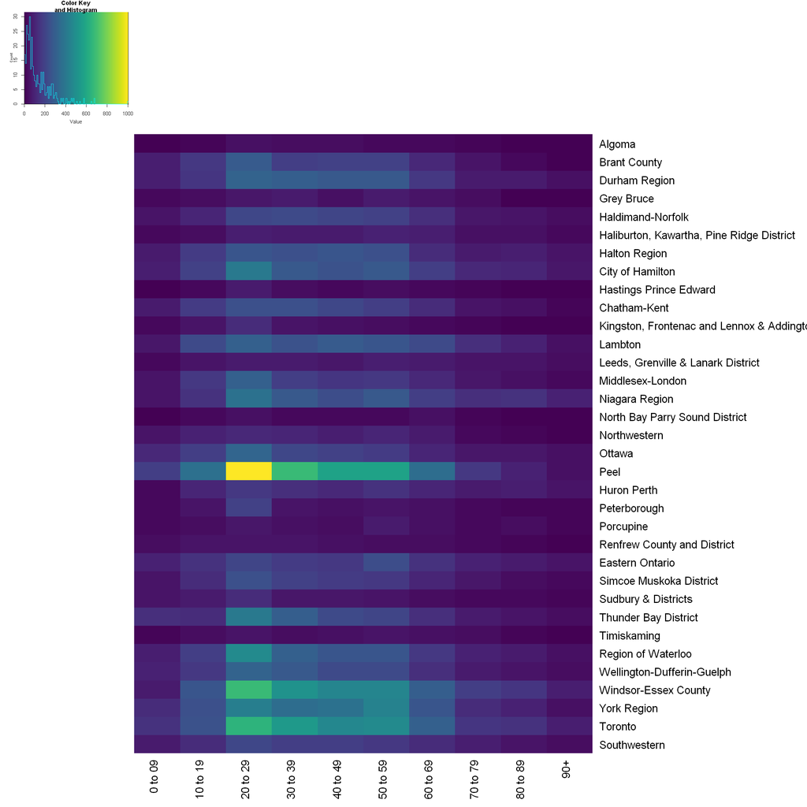

```r
# Adjust our plot window size according to the expected output
options(repr.plot.width=20, repr.plot.height=20)

# Plot our data without ordering. So it will be ordered as-is.

heatmap.2(x=(covid_demographics_norm.mx[,-11]), # get rid of our population information
          col = viridis(100), # Use the viridis colour scheme
          cexRow = 2, # Set row text size
          cexCol = 2, # Set column text size
          lhei = c(2,10), # Alter our key heigh slightly
          lwid = c(2, 10),
          margins=c(8,32), # Increase text margins because our PHU names can be big
          trace = "none", # Get rid of the trace line down columns
          Rowv = FALSE, Colv = "Rowv", # Here we've turned off the dendrograms
          dendrogram = "none" # Optional to turn off warnings
         )
```

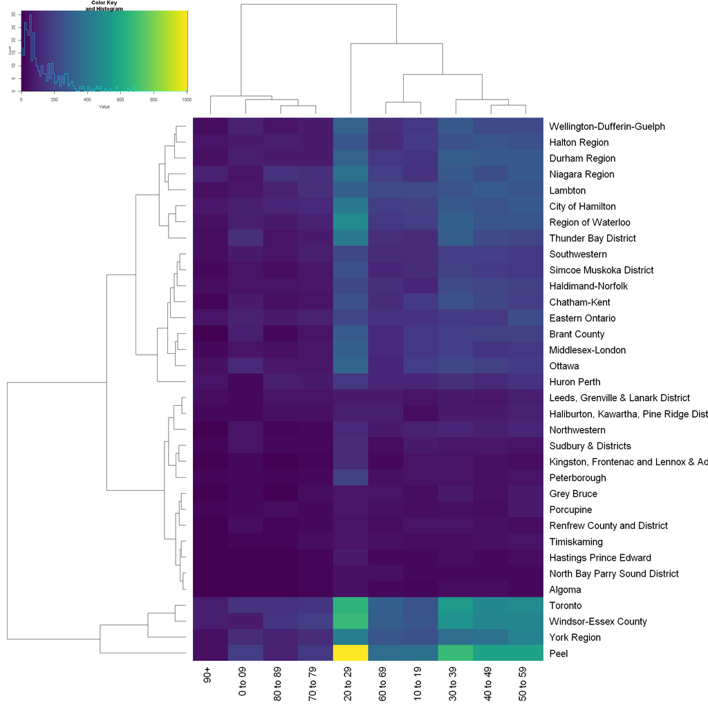

```r
# Adjust our plot window size according to the expected output
options(repr.plot.width=20, repr.plot.height=20)

heatmap.2(x=(covid_demographics_norm.mx[,-11]), # get rid of our population information
          col = viridis(100), # Use the viridis colour scheme
          cexRow = 2, # Set row text size
          cexCol = 2, # Set column text size
          lhei = c(2,10), # Alter our key heigh slightly
          margins=c(8,28), # Increase text margins because our PHU names can be big
          trace = "none" # Get rid of the trace line down columns
         )
```

## 1.4.0 Make a cluster dendrogram with `hclust()`

As you can see, clustering our data makes a big difference in how our data is displayed. In our previous commands, we allowed `heatmap.2()` to generate it's own clustering. We could have supplied it with a specific dendrogram to order the data as well. Under the hood, the function is actually calling on the `hclust()` function to produce the dendrograms.

The choice of `method` determines how the data is clustered. The choices include: ward.D, ward.D2, single, complete (default), average, mcquitty, median and centroid.

In *general* ward.D, ward.D2 and complete strategies try to find compact small "spherical" clusters. The single linkage adopts a 'friends of friends' clusterin strategy. The other methods can be said to aim for somewhere in between. For more information on these, you can dig into the `hclust()` [documentation](https://stat.ethz.ch/R-manual/R-patched/library/stats/html/hclust.html)

We can turn to `hclust()` to generate just dendrograms for us but prior to that we still need to reformat our matrix a little using the `dist()` function.

## 1.4.1 Calculate the distance between our points with `dist()`

Remember we talked about our data being in n-dimensional space? Using those coordinates, there are a number of ways to calculate the distance between points. The simplest form is to calculate the euclidean distance between points using the generic formula:

$d(p,q) = \sqrt{(p_{1}-q_{2})^2 + (p_{2}-q_{2})^2 + \ldots + (p_{n}-q_{n})^2}$

but there are a number of other options as well. For isntance you can also choose the maximum distance between two components (same dimension). The `dist()` function can generate these values for you using the parameter `method` to determine how the distance will be used. Your options are: euclidean, maximum, manhattan, canberra, binary or minkowski.

The `dist()` function will return a `dist` object which is a lower triangle distance matrix between all of the rows/observations using the columns as coordinates.

Let's try it out and see how it works.

```r
dist(covid_demographics_norm.mx[,-11],
     method="euclidean") # The default method is euclidean
```

```
                                               Algoma Brant County
Brant County                                425.04956
Durham Region                               574.69662    183.69613
Grey Bruce                                   86.46478    352.61788
Haldimand-Norfolk                           399.94183    114.91332
Haliburton, Kawartha, Pine Ridge District   133.66575    318.31532
Halton Region                               498.05683    130.00119
City of Hamilton                            629.14738    228.72335
Hastings Prince Edward                       37.25335    397.33899
Chatham-Kent                                439.30588     83.07491
Kingston, Frontenac and Lennox & Addington   93.72505    349.52256
Lambton                                     597.56725    219.48246
Leeds, Grenville & Lanark District          136.09346    329.62354
Middlesex-London                            409.29675     68.98081
Niagara Region                              604.83783    247.26299
North Bay Parry Sound District               24.39243    424.01382
Northwestern                                180.48152    254.02003
Ottawa                                      473.02709     88.19617
Peel                                       1503.84307   1088.22459
Huron Perth                                 273.72405    207.07991
Peterborough                                168.63209    299.11059
Porcupine                                    78.70829    367.10716
Renfrew County and District                  67.07709    375.26304
Eastern Ontario                             406.34353    128.38082
Simcoe Muskoka District                     366.97786     80.38170
Sudbury & Districts                         132.62741    304.95668
Thunder Bay District                        565.91540    180.48235
Timiskaming                                  50.37468    384.94967
Region of Waterloo                          665.95299    259.58362
Wellington-Dufferin-Guelph                  516.79738    120.32516
Windsor-Essex County                       1097.07237    692.17366
York Region                                 840.76948    435.41099
Toronto                                    1110.76002    702.39639
Southwestern                                368.77524    105.10328
                                           Durham Region Grey Bruce
Brant County
Durham Region
Grey Bruce                                     497.69117
Haldimand-Norfolk                              177.64376  323.63347
Haliburton, Kawartha, Pine Ridge District      455.08484   60.54348
```

[output cut: 693 more lines]

```
Huron Perth
Peterborough
Porcupine
Renfrew County and District
Eastern Ontario
Simcoe Muskoka District
Sudbury & Districts
Thunder Bay District
Timiskaming
Region of Waterloo
Wellington-Dufferin-Guelph
Windsor-Essex County
York Region
Toronto
Southwestern                                749.51003
```

## 1.4.2 Cluster your distance matrix

Now we are ready to cluster our distance matrix using the `hclust()` method

Parameters that are important

- `method` already as described the method which we want to use to cluster our data.
  - ward.D, ward.D2, single, complete (default), average, mcquitty, median and centroid.
- `k` is the number of groups we would like our final data to be split into - represented by colours

```r
# Make a cluster object and take a look at it
phu.hc <- hclust(dist(covid_demographics_norm.mx[,-11]), method = "ward.D2")

str(phu.hc)

# phu.hc$merge
```

```
List of 7
 $ merge      : int [1:33, 1:2] -1 -6 -9 -4 -25 1 -11 -23 -2 -5 ...
 $ height     : num [1:33] 24.4 33.8 39.7 39.7 52.3 ...
 $ order      : int [1:34] 19 32 31 33 20 17 6 13 21 11 ...
 $ labels     : chr [1:34] "Algoma" "Brant County" "Durham Region" "Grey Bruce" ...
 $ method     : chr "ward.D2"
 $ call       : language hclust(d = dist(covid_demographics_norm.mx[, -11]), method = "ward.D2")
 $ dist.method: chr "euclidean"
 - attr(*, "class")= chr "hclust"
```

## 1.4.3 Plot your cluster object using `fviz_dend()` from the package `factoextra`

Now that we have generated our clustering object, you can see that it holds a number of features including the height (length) of our branches, an ordering of our PHUs and the order in which they merge. The `merge` process is described in more detail as well with the `hclust()` [documentation](https://stat.ethz.ch/R-manual/R-patched/library/stats/html/hclust.html)

To simplify the plotting process, we can use the `fviz_dend()` function which will parse through the `hclust` object to produce a proper dendrogram. We can even specify some grouping or colouring schemes based on how many groups, `k`, we believe are present in our data.

We can treat the resulting plot like a ggplot to update particular elements as well.

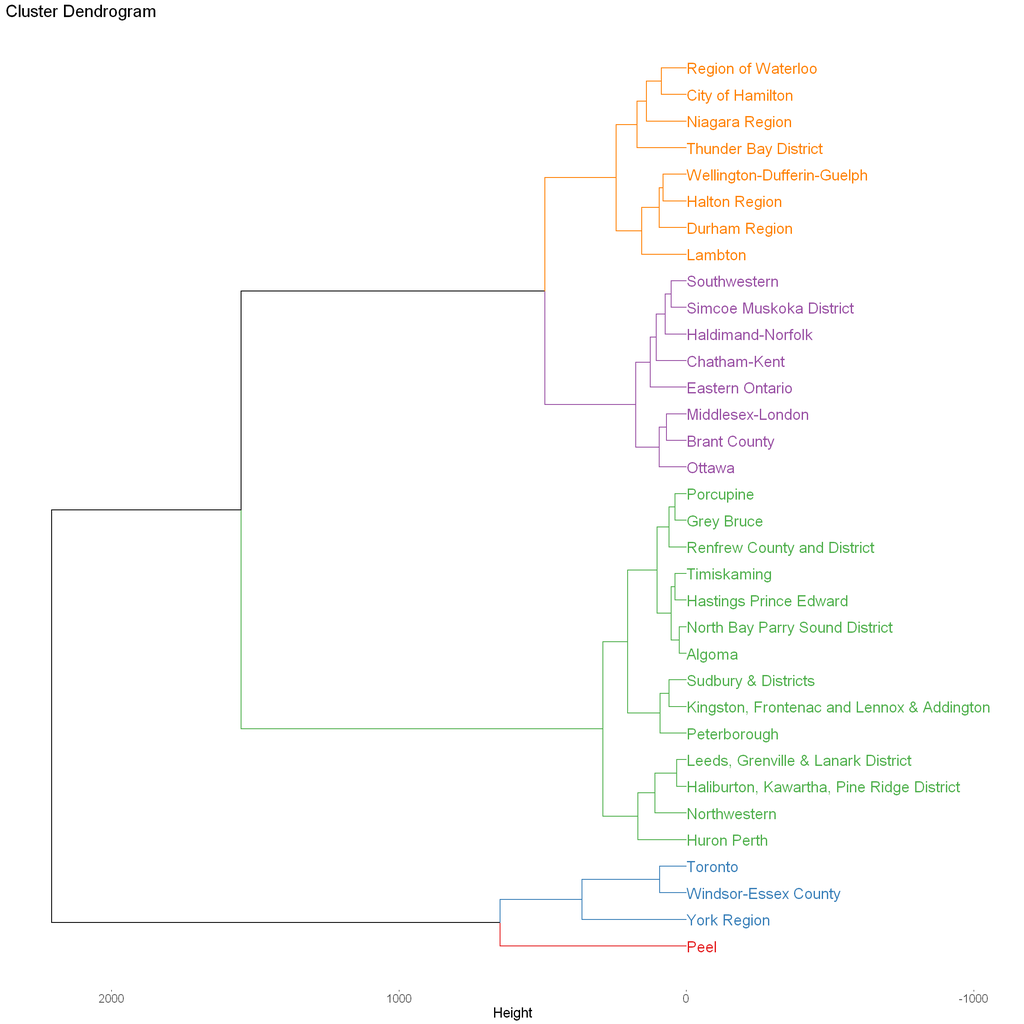

```r
# Plot out our dendrogram

fviz_dend(phu.hc, # provide our hclust object
          cex = 1.5, # set the text size to be larger
          k = 5, # How many clusters do we expect in our data
          palette = "Set1", # what colours will we use. Many options including RBrewer palettes
          horiz = TRUE,
          labels_track_height = 1000,
         ) +
theme(text = element_text(size = 20)) # Bump up the text size for my old eyes
```

## 2.0.0 Cluster on our dataset using the 10 dimensions of data

So we've visualized our dataset as a dendrogram and it gives us an idea of how the samples might be related (in space) based on the values we produced from normalization.

K-means clustering is unsupervised learning for uncategorized data. We don't really know the training labels of our data and are more interested in seeing which ones group together. How many clusters should we aim to generate? We've already seen that our data likely splits into 3 groups based on the heatmaps and `hclust()` data. Will we get the same thing with a k-means method?

When in doubt, you can quickly consult the `factoMiner` function `fviz_nbclust()` which can guess how many clusters you are ideal for representing your data. Note that it my not produce your ideal number of clusters but if you're stuck, this is a good start.

There are three `method` options: wss, gap_stat, and silhouette which all aim to minimize the number of clusters.

- `wss` elbow method aims to minimize intracluster variation. How compact is our clustering? A lower WSS is better.
- `silhouette` measures how well an object lies within it's cluster by computing the average distance to other members in its own, $a(i)$ vs other clusters $b(i)$. We evaluate $\frac{b(i) - a(i)}{max\{a(i), b(i)}$ with higher values indicating better clustering.
- `gap_stat` also compares total intra-cluster variation but against a null reference distribution. The optimal value attempts to choose the number of clusters such that the smallest `k` gap statistics is within one standard deviation of the gap at `k+1`.

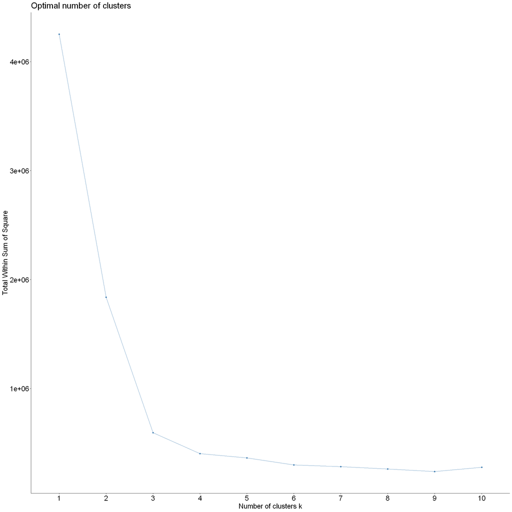

```r
# How many clusters should we generate?
fviz_nbclust(covid_demographics_norm.mx[,-11], kmeans, method="wss") +
    theme(text = element_text(size=20))
```

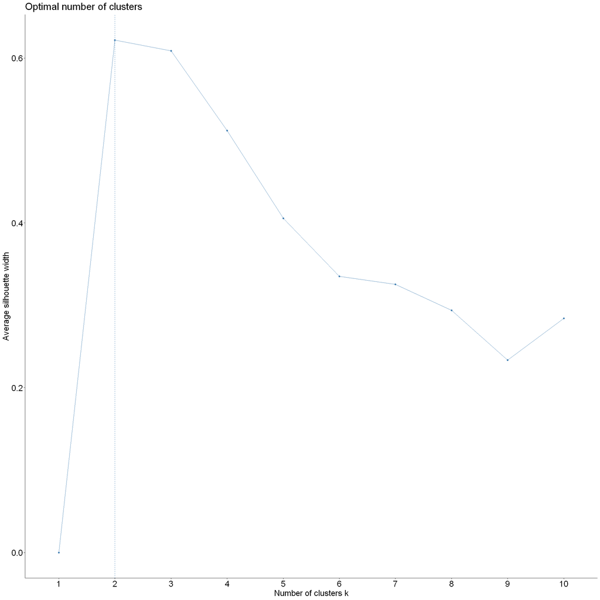

```r
# How many clusters should we generate?
fviz_nbclust(covid_demographics_norm.mx[,-11], kmeans, method="silhouette") +
    theme(text = element_text(size=20))
```

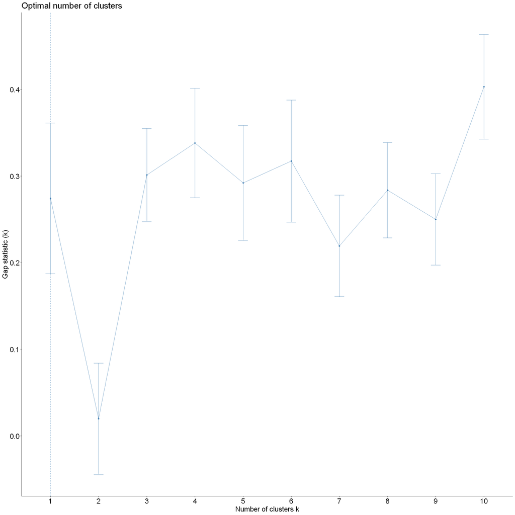

```r
# How many clusters should we generate?
fviz_nbclust(covid_demographics_norm.mx[,-11], kmeans, method="gap_stat") +
    theme(text = element_text(size=20))
```

## 2.1.0 Generate your clusters using `kmeans()`

So from three different analyses we didn't really get a concensus on the best number of clusters but it looks like the answer ranges between 1 and 3 clusters. Since our data already suggests 3 clusters, let's start with that. We'll use the `kmeans()` function to accomplish this.

Similar in idea to `hclust()`, the `kmeans()` algorithm attempts to generate k-partioned groups from the data supplied with an emphasis on minimizing the sum of squares from points to the assigned cluster centers. This differs from `hclust()` which finishes building the entire relationship via dendrogram without actually choosing "clusters".

We're going to also use `set.seed()` for our random number generation. We tend to think of things as random, but computationally, randomness is built on algorithms. Therefore we can "recreate" our randomness if we use a pre-determined starting point also known as the "seed".

The parameters we're interested in using with `kmeans()` are:

- `x` the *numeric matrix* of our data
- `centers` determines the number of clusters we want to produce
- `nstart` defines how many randomly chosen sets of k centres you'll use to start the analysis
- `iter.max` is the max number of iterations allowed while trying to converge on the best minimum metric

```r
# Compute k-means with k = 3

# Set a seed for reproducibility.
set.seed(123)

# Generate our k-means analysis
phu_cases.km <-
kmeans(scale(covid_demographics_norm.mx[, -11]), # We'll scale our data for this (more on that later too!)
       centers = 3,
       nstart = 25,
       iter.max = 500)

# phu_cases_unscaled.km <- kmeans(covid_demographics_norm.mx[,-11], 3, nstart = 25)
```

```r
str(phu_cases.km)
```

```
List of 9
 $ cluster     : Named int [1:34] 2 1 1 2 1 2 1 1 2 1 ...
  ..- attr(*, "names")= chr [1:34] "Algoma" "Brant County" "Durham Region" "Grey Bruce" ...
 $ centers     : num [1:3, 1:10] 0.318 -0.904 1.586 0.342 -1.007 ...
  ..- attr(*, "dimnames")=List of 2
  .. ..$ : chr [1:3] "1" "2" "3"
  .. ..$ : chr [1:10] "0 to 09" "10 to 19" "20 to 29" "30 to 39" ...
 $ totss       : num 330
 $ withinss    : num [1:3] 40 9.3 17.9
 $ tot.withinss: num 67.2
 $ betweenss   : num 263
 $ size        : int [1:3] 17 13 4
 $ iter        : int 2
 $ ifault      : int 0
 - attr(*, "class")= chr "kmeans"
```

```r
# K-means clusters showing the group of each individuals
phu_cases.km$cluster
```

**Algoma**

2

**Brant County**

1

**Durham Region**

1

**Grey Bruce**

2

**Haldimand-Norfolk**

1

**Haliburton, Kawartha, Pine Ridge District**

2

**Halton Region**

1

**City of Hamilton**

1

**Hastings Prince Edward**

2

**Chatham-Kent**

1

**Kingston, Frontenac and Lennox & Addington**

2

**Lambton**

1

**Leeds, Grenville & Lanark District**

2

**Middlesex-London**

1

**Niagara Region**

1

**North Bay Parry Sound District**

2

**Northwestern**

2

**Ottawa**

1

**Peel**

3

**Huron Perth**

1

**Peterborough**

2

**Porcupine**

2

**Renfrew County and District**

2

**Eastern Ontario**

1

**Simcoe Muskoka District**

1

**Sudbury & Districts**

2

**Thunder Bay District**

1

**Timiskaming**

2

**Region of Waterloo**

1

**Wellington-Dufferin-Guelph**

1

**Windsor-Essex County**

3

**York Region**

3

**Toronto**

3

**Southwestern**

1

## 2.2.0 Plot your k-means results with `fviz_cluster()`

Notice the structure of this output? It includes `cluster` which denotes which row belongs to each of the 3 clusters chosen. The centre of each cluster is defined by `centers` which in this case is a 3x10 array where each row uses 10 values to define their position within our 10-dimensional dataset. We can see each cluster's `size` is 17, 13, and 4 PHUs respectively. Notice, however, that none of the original coordinates for our data are retained in this object.

Rather than use ggplot directly, we'll use the `fviz_cluster()` function to help us transform the values of our points from a 10-dimensional coordinate system to a 2-dimensional visual format suitable for our simpler brains. Under the hood `fviz_cluster()` is performing a principle component analysis to group our `data` along the first two principal components (more on what that means later).

The parameters we should be concerned with in this function include:

- `object` the partitioning object for our data. In the case of kmeans, it is our kmeans object.
- `data` is the original dataset we used to generate the data. This will be necessary to plot the other data points.
- `ellipse.type` determines how we'll outline our clusters. This comes with a number of options including:
  - convex: draws boundaries based on the outer points in your cluster
  - confidence: produces a confidence ellipse around the cluster centres. This can be further adjusted using the parameter `ellipse.level` whose default is 0.95.
  - t, norm: assume multivariate t-distribution and multivariate normal distributions to produce their ellipses using `ellipse.level` to set their radius.
  - euclid: sets a circle of radius `ellipse.level` around the centre of each cluster.

Let's see how our data has been partitioned by the k-means clustering.

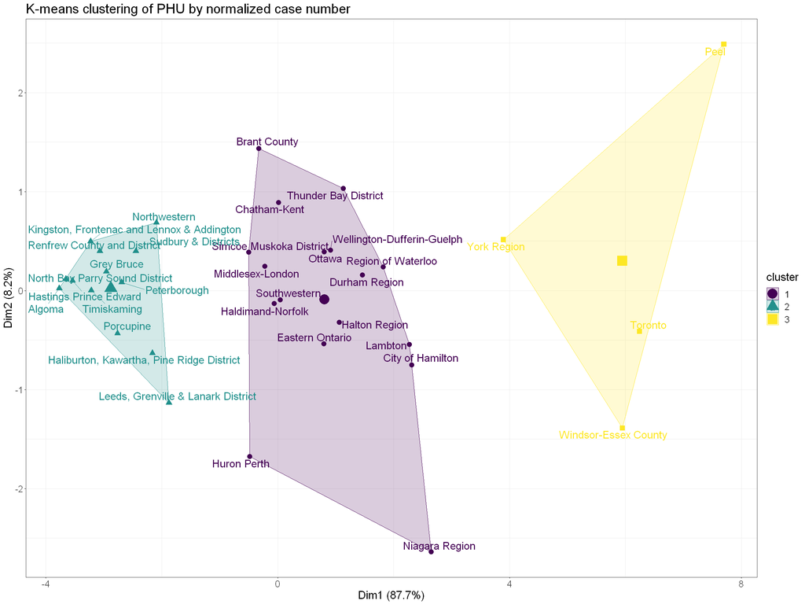

```r
# Adjust our plot window size according to the expected output
options(repr.plot.width=20, repr.plot.height=15)

# Plot the cluster
# You can treat this object like a ggplot object afterwards

phu_kmeans.plot <-

fviz_cluster(object = phu_cases.km, # our k-means object
             data = covid_demographics_norm.mx[, -11], # Our original data needed for PCA to visualize
             ellipse.type = "convex",
             ggtheme = theme_bw(),
             repel=TRUE, # Try to avoid overlapping text
             labelsize = 20,
             pointsize = 4,
             main = "K-means clustering of PHU by normalized case number"
             ) +

# Set some ggplot theme information
theme(text = element_text(size=20)) +

# Set the colour and fill scheme to viridis
scale_fill_viridis_d() +
scale_colour_viridis_d()

phu_kmeans.plot
```

## 2.3.1 Interpreting our clusters: normalization matters

Looking at our plot, it looks like the final clusters come close to matching our original heatmap interpretations and dendrograms. One thing looking back at the data is that these PHU clusters all appear grouped by their overall population size. It's not an exact 1:1 ordering but there appears to be a possible underlying influence. In trying to compare these different PHUs were we using the *correct* metric?

We *did* normalize the data to values per 100,000 residents in the PHU so that size of each PHU is taken into account but k-means can be sensitive to outliers. What we are seeing is a separation of our PHUs by virtue of their size because *in general* large PHUs will still produce high numbers of cases, even after normalizing.

What we really wanted to know was, if the PHUs all were similar based on the *proportion* of cases in each age group. That data can be found in `covid_demographics_percent.df`

```r
# Take a look at the normalized percentage version of our demographics data
head(covid_demographics_percent.df)
```

A grouped_df: 6 × 10

| from_date <chr> | to_date <chr> | public_health_unit <chr> | age_group <fct> | total_cases <dbl> | total_deaths <dbl> | total_hospitalizations_count <dbl> | percent_cases <dbl> | percent_deaths <dbl> | percent_hospitalizations <dbl> |
| --- | --- | --- | --- | --- | --- | --- | --- | --- | --- |
| January 15, 2020 | March 19, 2021 | Algoma | 0 to 09 | 0 | 0 | 0 | 0.00000000 | 0.00 | 0.0000000 |
| January 15, 2020 | March 19, 2021 | Algoma | 10 to 19 | 20 | 0 | 0 | 0.09174312 | 0.00 | 0.0000000 |
| January 15, 2020 | March 19, 2021 | Algoma | 20 to 29 | 49 | 1 | 0 | 0.22477064 | 0.25 | 0.0000000 |
| January 15, 2020 | March 19, 2021 | Algoma | 30 to 39 | 36 | 0 | 0 | 0.16513761 | 0.00 | 0.0000000 |
| January 15, 2020 | March 19, 2021 | Algoma | 40 to 49 | 36 | 0 | 1 | 0.16513761 | 0.00 | 0.1666667 |
| January 15, 2020 | March 19, 2021 | Algoma | 50 to 59 | 27 | 0 | 0 | 0.12385321 | 0.00 | 0.0000000 |

```r
# Work with the % cases data to make a wide-format dataset

covid_demographics_percent_norm.df <-

covid_demographics_percent.df %>%

# Only select for PHU, age group, and total_cases
select(3:4, 8) %>%

# Pivot wider to spread the age_group information across columns
pivot_wider(names_from = age_group,
            values_from = percent_cases
           ) %>%

# Join to the PHU information to get population size for each PHU
left_join(., y=phu_information.df[,c(1,8)])

# Take a look at the data
head(covid_demographics_percent_norm.df)


# Now we need to make our matrix and assign row names. It's kind of awkward to need this requirement.
covid_demographics_percent_norm.mx <-
    as.matrix(covid_demographics_percent_norm.df[, 2:ncol(covid_demographics_percent_norm.df)])

rownames(covid_demographics_percent_norm.mx) <- covid_demographics_percent_norm.df$public_health_unit

head(covid_demographics_percent_norm.mx)
```

A grouped_df: 6 × 12

| public_health_unit <chr> | 0 to 09 <dbl> | 10 to 19 <dbl> | 20 to 29 <dbl> | 30 to 39 <dbl> | 40 to 49 <dbl> | 50 to 59 <dbl> | 60 to 69 <dbl> | 70 to 79 <dbl> | 80 to 89 <dbl> | 90+ <dbl> | population <dbl> |
| --- | --- | --- | --- | --- | --- | --- | --- | --- | --- | --- | --- |
| Algoma | 0.00000000 | 0.09174312 | 0.2247706 | 0.1651376 | 0.1651376 | 0.1238532 | 0.12385321 | 0.06880734 | 0.02752294 | 0.009174312 | 114434 |
| Brant County | 0.06663400 | 0.12493876 | 0.2195002 | 0.1406173 | 0.1489466 | 0.1504165 | 0.08672220 | 0.04017638 | 0.01665850 | 0.005389515 | 155203 |
| Durham Region | 0.05042149 | 0.08878910 | 0.1784448 | 0.1652092 | 0.1561491 | 0.1559915 | 0.09532813 | 0.04482786 | 0.04010084 | 0.024738045 | 712402 |
| Grey Bruce | 0.05027933 | 0.08659218 | 0.1564246 | 0.1689944 | 0.1089385 | 0.1787709 | 0.14106145 | 0.07541899 | 0.02374302 | 0.009776536 | 169884 |
| Haldimand-Norfolk | 0.04169469 | 0.08338937 | 0.1694687 | 0.1741762 | 0.1607263 | 0.1479489 | 0.10087424 | 0.05312710 | 0.04303968 | 0.025554808 | 114081 |
| Haliburton, Kawartha, Pine Ridge District | 0.04170444 | 0.06255666 | 0.1468722 | 0.1305530 | 0.1233001 | 0.1586582 | 0.14687217 | 0.07524932 | 0.06980961 | 0.044424297 | 188937 |

A matrix: 6 × 11 of type dbl

|  | 0 to 09 | 10 to 19 | 20 to 29 | 30 to 39 | 40 to 49 | 50 to 59 | 60 to 69 | 70 to 79 | 80 to 89 | 90+ | population |
| --- | --- | --- | --- | --- | --- | --- | --- | --- | --- | --- | --- |
| Algoma | 0.00000000 | 0.09174312 | 0.2247706 | 0.1651376 | 0.1651376 | 0.1238532 | 0.12385321 | 0.06880734 | 0.02752294 | 0.009174312 | 114434 |
| Brant County | 0.06663400 | 0.12493876 | 0.2195002 | 0.1406173 | 0.1489466 | 0.1504165 | 0.08672220 | 0.04017638 | 0.01665850 | 0.005389515 | 155203 |
| Durham Region | 0.05042149 | 0.08878910 | 0.1784448 | 0.1652092 | 0.1561491 | 0.1559915 | 0.09532813 | 0.04482786 | 0.04010084 | 0.024738045 | 712402 |
| Grey Bruce | 0.05027933 | 0.08659218 | 0.1564246 | 0.1689944 | 0.1089385 | 0.1787709 | 0.14106145 | 0.07541899 | 0.02374302 | 0.009776536 | 169884 |
| Haldimand-Norfolk | 0.04169469 | 0.08338937 | 0.1694687 | 0.1741762 | 0.1607263 | 0.1479489 | 0.10087424 | 0.05312710 | 0.04303968 | 0.025554808 | 114081 |
| Haliburton, Kawartha, Pine Ridge District | 0.04170444 | 0.06255666 | 0.1468722 | 0.1305530 | 0.1233001 | 0.1586582 | 0.14687217 | 0.07524932 | 0.06980961 | 0.044424297 | 188937 |

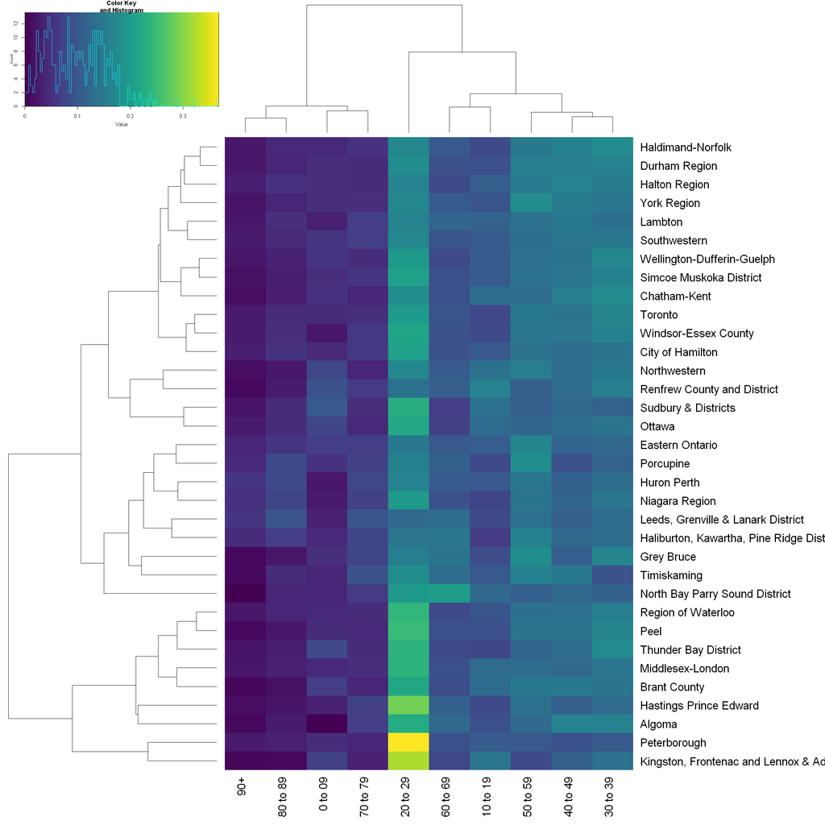

```r
# Adjust our plot window size according to the expected output
options(repr.plot.width=20, repr.plot.height=20)

heatmap.2(x=(covid_demographics_percent_norm.mx[,-11]), # get rid of our population information
          col = viridis(100), # Use the viridis colour scheme
          cexRow = 2, # Set row text size
          cexCol = 2, # Set column text size
          lhei = c(2,10), # Alter our key heigh slightly
          margins=c(8,28), # Increase text margins because our PHU names can be big
          trace = "none" # Get rid of the trace line down columns
         )
```

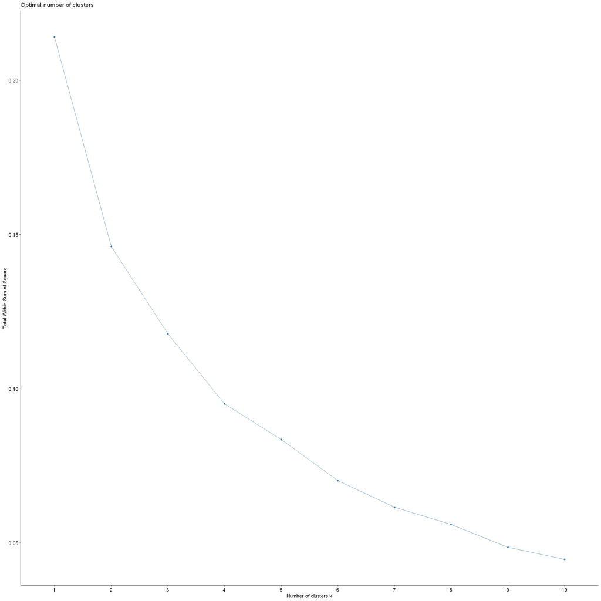

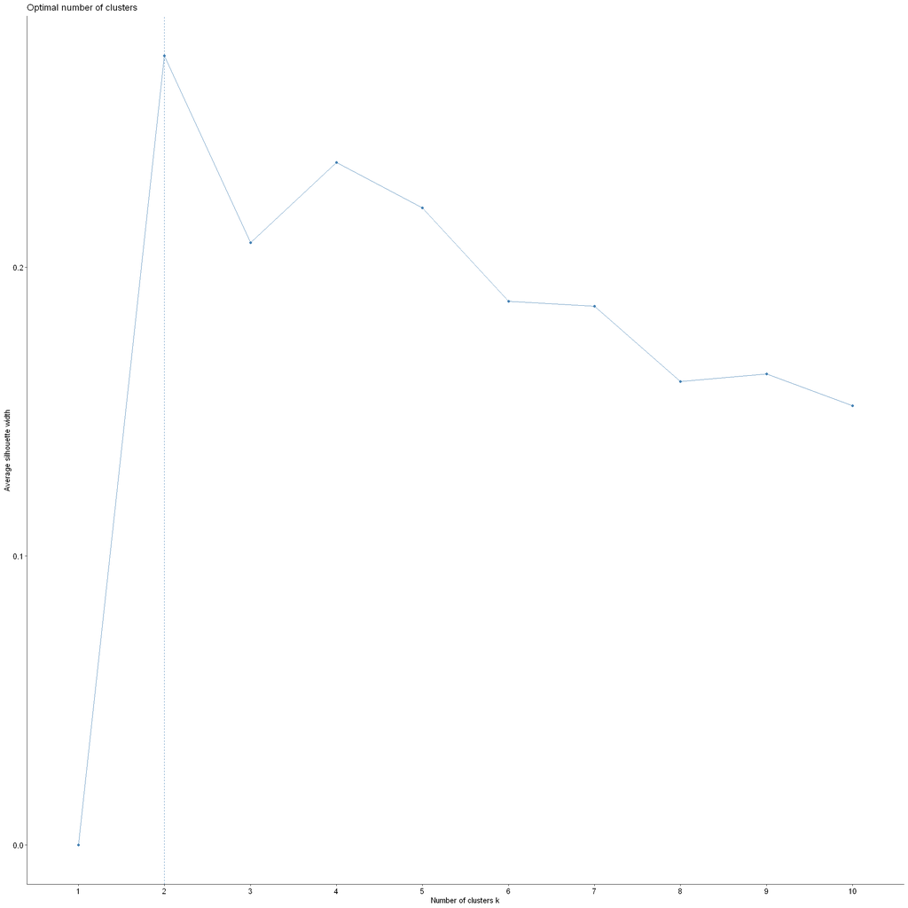

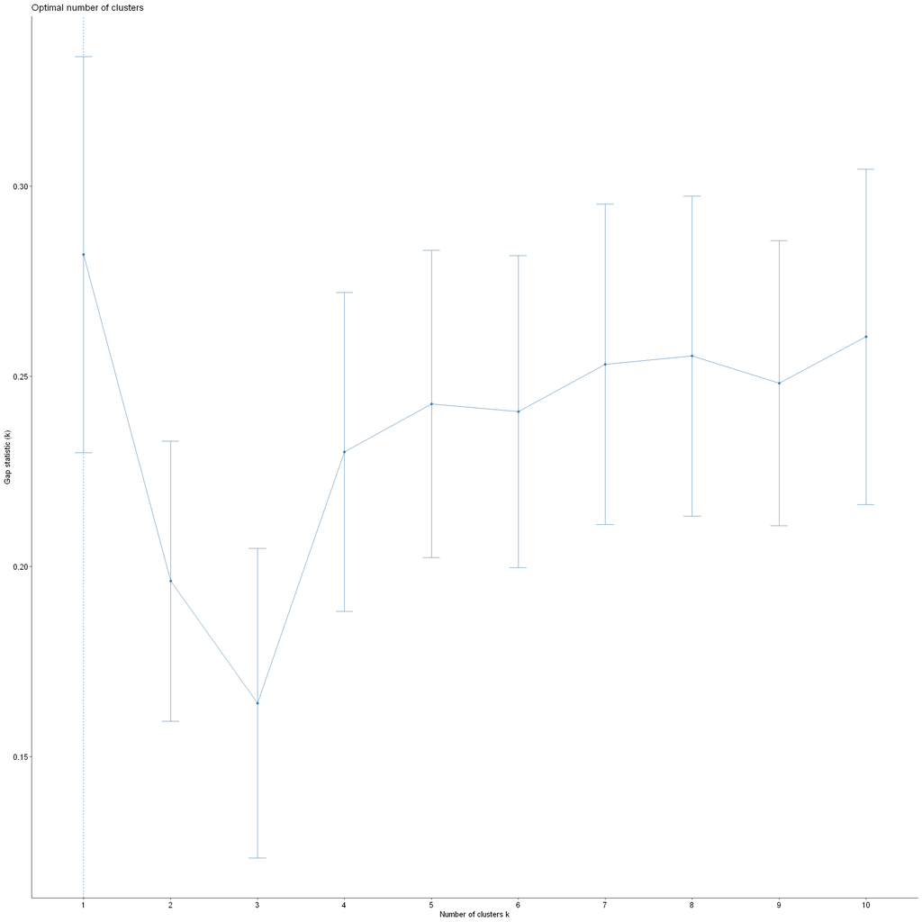

```r
# How many clusters should we generate?
fviz_nbclust(covid_demographics_percent_norm.mx[,-11], kmeans, method="wss")
fviz_nbclust(covid_demographics_percent_norm.mx[,-11], kmeans, method="silhouette")
fviz_nbclust(covid_demographics_percent_norm.mx[,-11], kmeans, method="gap_stat")
```

```r
# Compute k-means with k = 3
set.seed(123)
phu_percent_cases.km <- kmeans(scale(covid_demographics_percent_norm.mx[,-11]),
                               centers = 3,
                               nstart = 25)
```

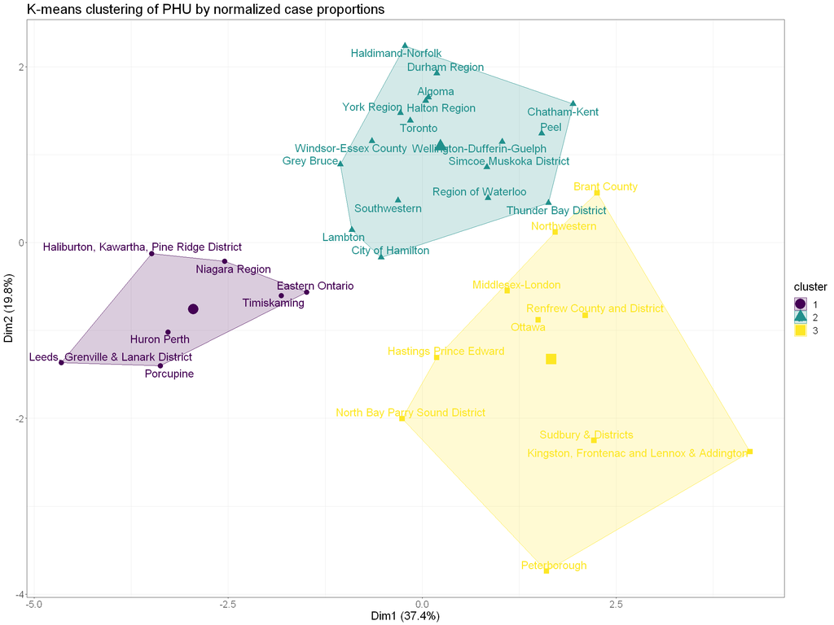

```r
# Adjust our plot window size according to the expected output
options(repr.plot.width=20, repr.plot.height=15)

# Plot the cluster
# You can treat this object like a ggplot object afterwards

fviz_cluster(phu_percent_cases.km, # our k-means object
             data = covid_demographics_percent_norm.mx[,-11], # Our original data needed for PCA to visualize
             ellipse.type = "convex",
             ggtheme = theme_bw(),
             repel=TRUE, # Try to avoid overlapping text
             labelsize = 20,
             pointsize = 4,
             main = "K-means clustering of PHU by normalized case proportions"
             ) +

# Set some ggplot theme information
theme(text = element_text(size=20)) +

# Set the colour and fill scheme to viridis
scale_fill_viridis_d() +
scale_colour_viridis_d()
```

## 2.3.2 Interpretating our updated clustering

Now that we've changed our data representation to look more closely at proportion of cases across age groups, we no longer see stratification by PHU size. Our goal now could be to look deeper into those PHUs to see if other features or information about these PHUs can help explain their proportions. PHU size could still play a role but it no longer has such a strong influence on our clustering.

Eyeing all of our data this way suggests that our data isn't very diverse which could be interpreted as no PHUs appear to be drastically different from each other in the proportion of cases by age group. Let's explore this set further with some additional methods to see if we can determine any more from it.

## 3.0.0 Dimensionality reduction

You can achieve dimensionality reduction in three general ways:

1. **Feature elimination**: you can reduce the feature space by removing unhelpful features. No information is gained but you trim down your dataset size.
1. **Feature selection**: on the reverse side you can simply choose the most important features to you. How will you decide? Some schemes include ranking your features by importance but this may suffer from information loss if incorrect features are chosen.
1. **Feature extraction**: create new independent features which are a combination of the old features! Attempt to extract the essential features of your data in a more informationally dense manner.

[output not shown]

Since we're not exactly building a classifier but rather trying to find trends in our data, we won't be looking at Random Forests here. Here we are interested in *exploratory data analysis*. We have a data set we want to understand, sometimes it is too complex to just project or divine 1) the underlying structure and 2) the features that drive that structure.

## 3.1.0 Reduce your dimensionality with PCA

We used 10 dimensions above to classify our data but what if we wanted to transform that information in some way to reduce the number of dimensions needed to represent their relationships? For our data set, 10 dimensions isn't a lot of features but in other cases you might encounter feature-dense datasets and without knowing a priori which ones are meaningful, PCA provides a path forward in classifying our data.

Now there are caveats to PCA. It produces linear feature extraction by building new features in your n-dimensional space such that each new feature (kind of like a projected line) maximizes variance to the original data points. Each new component must be uncorrelated with or perpendicular to the previous ones while accounting for the next highest variance. More resources on how this work in the references.

All math aside, our goal is to reduce our feature set to something smaller by trying to represent our data with these new features. Just remember that highly variable data and outliers can dominate your principal components.

For simplicity let's head back and look at our PHU age group data again. To illustrate our example with PCA, let's use the original data normalized by PHU population.

```r
# Look at our covid demographics population-normalized data
head(covid_demographics_norm.mx)
```

A matrix: 6 × 11 of type dbl

|  | 0 to 09 | 10 to 19 | 20 to 29 | 30 to 39 | 40 to 49 | 50 to 59 | 60 to 69 | 70 to 79 | 80 to 89 | 90+ | population |
| --- | --- | --- | --- | --- | --- | --- | --- | --- | --- | --- | --- |
| Algoma | 0.00000 | 17.47732 | 42.81944 | 31.45918 | 31.45918 | 23.59439 | 23.59439 | 13.10799 | 5.243197 | 1.747732 | 114434 |
| Brant County | 87.62717 | 164.30095 | 288.65421 | 184.91911 | 195.87250 | 197.80545 | 114.04419 | 52.83403 | 21.906793 | 7.087492 | 155203 |
| Durham Region | 89.83692 | 158.19720 | 317.93847 | 294.35628 | 278.21371 | 277.93296 | 169.84792 | 79.87063 | 71.448424 | 44.076238 | 712402 |
| Grey Bruce | 21.19093 | 36.49549 | 65.92734 | 71.22507 | 45.91368 | 75.34553 | 59.45233 | 31.78640 | 10.006828 | 4.120459 | 169884 |
| Haldimand-Norfolk | 54.34735 | 108.69470 | 220.89568 | 227.03167 | 209.50027 | 192.84543 | 131.48552 | 69.24904 | 56.100490 | 33.309666 | 114081 |
| Haliburton, Kawartha, Pine Ridge District | 24.34674 | 36.52011 | 85.74287 | 76.21588 | 71.98167 | 92.62347 | 85.74287 | 43.92999 | 40.754326 | 25.934571 | 188937 |

## 3.2.0 Use `PCA()` to generate our analysis

To generate our analysis of the PHU data, we'll use the `FactoMineR` function `PCA()` for which there are some parameters we'll be using that we should discuss:

- `X` a data frame of *n* rows (observations) and *p* columns (numeric variables)
- `ncp` the number of dimensions kept in the results (5 is the default)
- `scale.unit` a boolean to scale your data (TRUE by default)

### 3.2.0.1 What does it mean to scale our data?

Remember that PCA is trying to maximize distance between a principle component and all of the observations supplied. Depending on the nature of your variables you may have, for instance, two different unit types like height and mass. Smaller changes in height may be matched with much larger changes in mass or just wider overall variance. This may lead the PCA algorithm to prioritize mass over height when you'd prefer they have an equal importance. By centering your mean and scaling data to unit variance, everything is compared as a z-score bringing the overall variance across a variable to within ~3 standard deviations.

Let's compare PCA with and without scaling shall we?

```r
# Build a PCA of our PHU data with scaling applied
phu_scaled.pca <- PCA(covid_demographics_norm.mx[,-11],
                      scale.unit = TRUE, # What happens when we don't scale the data?
                      ncp = 10,
                      graph = TRUE)

# Build a PCA of our PHU data WITHOUT scaling applied
phu_unscaled.pca <- PCA(covid_demographics_norm.mx[,-11],
                        scale.unit = FALSE,
                        ncp = 10,
                        graph = TRUE)
```

[output not shown]

```r
# Take a look at the information inside our PCA object
print(phu_scaled.pca)
```

```
**Results for the Principal Component Analysis (PCA)**
The analysis was performed on 34 individuals, described by 10 variables
*The results are available in the following objects:

   name               description
1  "$eig"             "eigenvalues"
2  "$var"             "results for the variables"
3  "$var$coord"       "coord. for the variables"
4  "$var$cor"         "correlations variables - dimensions"
5  "$var$cos2"        "cos2 for the variables"
6  "$var$contrib"     "contributions of the variables"
7  "$ind"             "results for the individuals"
8  "$ind$coord"       "coord. for the individuals"
9  "$ind$cos2"        "cos2 for the individuals"
10 "$ind$contrib"     "contributions of the individuals"
11 "$call"            "summary statistics"
12 "$call$centre"     "mean of the variables"
13 "$call$ecart.type" "standard error of the variables"
14 "$call$row.w"      "weights for the individuals"
15 "$call$col.w"      "weights for the variables"
```

## 3.3.0 Our PCA object has a complex number of data pieces

Regardless of scaling, the result of our `PCA()` call produces an object with many variables we can access. Above you can see a brief description for each variable but we are most interested in a few particular ones:

- `eig` holds our dimensional data but also describes just how much each new principle component describes the overall variation of our data.
- `var` holds the results of all the variables. We can use these to graph and visualize our data.
- `ind$coord` will allow us to plot the coordinates of our observations along the principal components.

## 3.4.0 Use the eigenvalues to determine the percent variance of each component

The eigenvalues from our analysis pair with a the eigenvectors (principle components) to help transform our data from the original feature set to the new set of features. While the eigenvectors may determine the directions of the new feature space, the *eigenvalue* represents the **magnitude** of the vector and in this case can be used to calculate the percent of overall variance explained by our eigenvector.

The important take-away is that we can now see just how much of our variance is explained in each new principle component. We can access this information directly from `phu_scaled.pca` or by using the function `get_eigenvalue()`. We can also plot this as a barchart instead using `fviz_eig()`.

```r
# Look at our eigenvalues directly
phu_scaled.pca$eig

# Use get_eigenvalue() to look at our eigenvalues
get_eigenvalue(phu_scaled.pca)
```

A matrix: 10 × 3 of type dbl

|  | eigenvalue | percentage of variance | cumulative percentage of variance |
| --- | --- | --- | --- |
| comp 1 | 8.768651730 | 87.68651730 | 87.68652 |
| comp 2 | 0.821462574 | 8.21462574 | 95.90114 |
| comp 3 | 0.191567669 | 1.91567669 | 97.81682 |
| comp 4 | 0.087668916 | 0.87668916 | 98.69351 |
| comp 5 | 0.062967541 | 0.62967541 | 99.32318 |
| comp 6 | 0.036241885 | 0.36241885 | 99.68560 |
| comp 7 | 0.015932547 | 0.15932547 | 99.84493 |
| comp 8 | 0.007751897 | 0.07751897 | 99.92245 |
| comp 9 | 0.005053484 | 0.05053484 | 99.97298 |
| comp 10 | 0.002701757 | 0.02701757 | 100.00000 |

A matrix: 10 × 3 of type dbl

|  | eigenvalue | variance.percent | cumulative.variance.percent |
| --- | --- | --- | --- |
| Dim.1 | 8.768651730 | 87.68651730 | 87.68652 |
| Dim.2 | 0.821462574 | 8.21462574 | 95.90114 |
| Dim.3 | 0.191567669 | 1.91567669 | 97.81682 |
| Dim.4 | 0.087668916 | 0.87668916 | 98.69351 |
| Dim.5 | 0.062967541 | 0.62967541 | 99.32318 |
| Dim.6 | 0.036241885 | 0.36241885 | 99.68560 |
| Dim.7 | 0.015932547 | 0.15932547 | 99.84493 |
| Dim.8 | 0.007751897 | 0.07751897 | 99.92245 |
| Dim.9 | 0.005053484 | 0.05053484 | 99.97298 |
| Dim.10 | 0.002701757 | 0.02701757 | 100.00000 |

## 3.4.1 Build a scree plot to look at the effect of your dimensions

See how nearly 88% of our variation is explained in dimension 1 now?

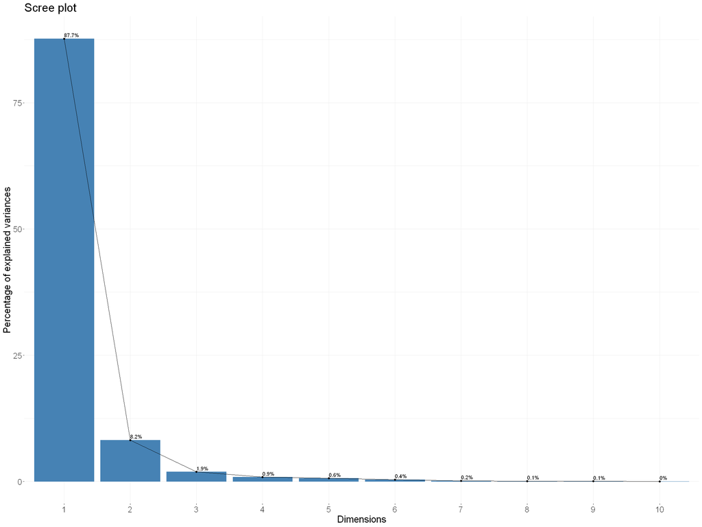

```r
# Visualize the impact of our eigenvalues
fviz_eig(phu_scaled.pca, addlabels = TRUE) + theme(text = element_text(size=20))
```

## 3.5.0 Most of our variance is accounted for in the first two principle components!

Looking at our eigenvalues we can see that even though 10 new PCs were generated, the first two explain almost 96% of our variance. That suggests that whatever *linear* separation in our data exists, we can recreate in a two-dimensional projection of coordinates from PC1 and PC2. This suggests that we can recreate the underlying structure of our data with these two new features instead of using a 10-dimensional space!

This makes some sense when we take a closer look at the data. For instance, there isn't much visual information found in our `0 to 09` and `90+` age ranges. The small distribution of information in these features may not do much, in the grand scheme, to change how the PHUs are separated from each other. Then again, perhaps they *do* contain information that we simply cannot see easily! How will we know?

## 3.6.0 Investigate your variables with `get_pca_var()`

Within our PCA, we can access information regarding how our original variables are transformed into the new space. This is all stored in the `var` element of our PCA object. We can extract the aspects of this using the `get_pca_var()` and visualize these to determine the quality of our variables and their representation by the new principal components.

```r
# What is the information associated with our original variables
phu.var <- get_pca_var(phu_scaled.pca)

phu.var
```

```
Principal Component Analysis Results for variables
 ===================================================
  Name       Description
1 "$coord"   "Coordinates for the variables"
2 "$cor"     "Correlations between variables and dimensions"
3 "$cos2"    "Cos2 for the variables"
4 "$contrib" "contributions of the variables"
```

## 3.6.1 What is the contribution of each variable to the new components?

Each original variable may, to some degree, influence the amount of information captured into each new principal component. When we look at each we can see the breakdown of variables, which in some cases, can reveal to us where more or less variation is found as well.

```r
# What is the contribution of each variable?
phu.var$contrib
```

A matrix: 10 × 10 of type dbl

|  | Dim.1 | Dim.2 | Dim.3 | Dim.4 | Dim.5 | Dim.6 | Dim.7 | Dim.8 | Dim.9 | Dim.10 |
| --- | --- | --- | --- | --- | --- | --- | --- | --- | --- | --- |
| 0 to 09 | 8.225581 | 18.69740073 | 62.84839662 | 0.03430399 | 5.6153664 | 2.9920941 | 0.07212868 | 0.04336713 | 1.4084225 | 0.06293841 |
| 10 to 19 | 10.331872 | 4.67377659 | 0.05178699 | 18.97618550 | 61.3884914 | 0.0398115 | 0.01878398 | 0.26673537 | 4.1492792 | 0.10327767 |
| 20 to 29 | 10.237007 | 4.73114360 | 4.67877532 | 51.70776176 | 7.1742284 | 8.6802808 | 8.35509815 | 0.02254223 | 3.3063477 | 1.10681475 |
| 30 to 39 | 10.917263 | 2.47439193 | 2.03057131 | 9.64155275 | 1.8838846 | 8.9979326 | 25.50043420 | 0.89518911 | 18.6013066 | 19.05747347 |
| 40 to 49 | 11.013098 | 2.03245602 | 3.19920369 | 0.71375269 | 0.6207367 | 18.0909364 | 11.41095723 | 5.32242573 | 16.3974620 | 31.19897175 |
| 50 to 59 | 11.087334 | 0.54994810 | 1.99152663 | 3.09248912 | 8.1449907 | 8.9402805 | 43.50804883 | 15.77547822 | 1.5313527 | 5.37855079 |
| 60 to 69 | 11.025459 | 0.01301614 | 7.35621088 | 7.11465152 | 11.1030941 | 3.1948248 | 1.93225437 | 54.27041674 | 0.3255935 | 3.66447886 |
| 70 to 79 | 10.565075 | 5.28655957 | 3.05809396 | 4.04582883 | 2.1310312 | 45.4826253 | 8.15626588 | 20.57564894 | 0.5966983 | 0.10217338 |
| 80 to 89 | 9.035692 | 24.48079093 | 1.25816421 | 0.03970202 | 1.4976542 | 1.4053279 | 0.10711201 | 2.81976616 | 36.3321022 | 23.02368861 |
| 90+ | 7.561618 | 37.06051639 | 13.52727038 | 4.63377182 | 0.4405222 | 2.1758861 | 0.93891667 | 0.00843038 | 17.3514354 | 16.30163232 |

From above we can see that our original variables equally contribute to our first principal component but there is much more contribution in PC2 from three variables: 0 to 9, 80 to 89 and 90+. From our previous scree plot that means that 8% of overall variation described in PC2 is mainly from these three groups.

## 3.6.2 The quality and representation of your variables in the PCA

From the remaining variable information `coord` and `cor` can both be used to plot our original variables on along different pairs of principal components. These values are the same because this is not a *projection* of our variables onto the PCs but a correlation of them! The distance between the origin and the variable coordinates gauges the quality of the variables on the map. This number is summarized in the `cos2` (squared cosine) element.

```r
# Look at the coordinates of our variables across the PCs.
phu.var$coord
phu.var$cor
```

A matrix: 10 × 10 of type dbl

|  | Dim.1 | Dim.2 | Dim.3 | Dim.4 | Dim.5 | Dim.6 | Dim.7 | Dim.8 | Dim.9 | Dim.10 |
| --- | --- | --- | --- | --- | --- | --- | --- | --- | --- | --- |
| 0 to 09 | 0.8492777 | -0.39190834 | 0.346983009 | -0.005483971 | -0.05946308 | 0.032930097 | -0.003389976 | 0.0018335144 | -0.008436492 | -0.001304010 |
| 10 to 19 | 0.9518224 | -0.19594215 | 0.009960277 | -0.128981456 | 0.19660830 | -0.003798478 | 0.001729962 | 0.0045472027 | 0.014480440 | -0.001670423 |
| 20 to 29 | 0.9474426 | -0.19714100 | -0.094673232 | 0.212912269 | 0.06721187 | 0.056088300 | 0.036485339 | 0.0013219117 | -0.012926165 | 0.005468405 |
| 30 to 39 | 0.9784155 | -0.14257000 | -0.062369208 | 0.091938266 | -0.03444177 | -0.057105344 | -0.063740636 | 0.0083303147 | 0.030659648 | -0.022691115 |
| 40 to 49 | 0.9827005 | -0.12921248 | -0.078285631 | -0.025014781 | -0.01977025 | -0.080972195 | -0.042638669 | -0.0203122866 | -0.028786161 | 0.029033093 |
| 50 to 59 | 0.9860070 | -0.06721323 | -0.061766667 | -0.052068721 | -0.07161495 | -0.056922106 | 0.083258275 | -0.0349699714 | 0.008796969 | -0.012054683 |
| 60 to 69 | 0.9832518 | -0.01034034 | -0.118710243 | -0.078976818 | -0.08361427 | 0.034027411 | 0.017545864 | 0.0648612910 | 0.004056330 | 0.009950142 |
| 70 to 79 | 0.9625043 | 0.20839172 | -0.076539659 | -0.059556144 | -0.03663138 | 0.128389099 | -0.036048591 | -0.0399374913 | 0.005491270 | -0.001661468 |
| 80 to 89 | 0.8901170 | 0.44844234 | 0.049094153 | -0.005899689 | 0.03070889 | -0.022568060 | -0.004131062 | 0.0147846333 | -0.042849001 | -0.024940814 |
| 90+ | 0.8142800 | 0.55175925 | 0.160977876 | 0.063736783 | 0.01665491 | -0.028081704 | 0.012230836 | 0.0008084024 | 0.029611687 | 0.020986437 |

A matrix: 10 × 10 of type dbl

|  | Dim.1 | Dim.2 | Dim.3 | Dim.4 | Dim.5 | Dim.6 | Dim.7 | Dim.8 | Dim.9 | Dim.10 |
| --- | --- | --- | --- | --- | --- | --- | --- | --- | --- | --- |
| 0 to 09 | 0.8492777 | -0.39190834 | 0.346983009 | -0.005483971 | -0.05946308 | 0.032930097 | -0.003389976 | 0.0018335144 | -0.008436492 | -0.001304010 |
| 10 to 19 | 0.9518224 | -0.19594215 | 0.009960277 | -0.128981456 | 0.19660830 | -0.003798478 | 0.001729962 | 0.0045472027 | 0.014480440 | -0.001670423 |
| 20 to 29 | 0.9474426 | -0.19714100 | -0.094673232 | 0.212912269 | 0.06721187 | 0.056088300 | 0.036485339 | 0.0013219117 | -0.012926165 | 0.005468405 |
| 30 to 39 | 0.9784155 | -0.14257000 | -0.062369208 | 0.091938266 | -0.03444177 | -0.057105344 | -0.063740636 | 0.0083303147 | 0.030659648 | -0.022691115 |
| 40 to 49 | 0.9827005 | -0.12921248 | -0.078285631 | -0.025014781 | -0.01977025 | -0.080972195 | -0.042638669 | -0.0203122866 | -0.028786161 | 0.029033093 |
| 50 to 59 | 0.9860070 | -0.06721323 | -0.061766667 | -0.052068721 | -0.07161495 | -0.056922106 | 0.083258275 | -0.0349699714 | 0.008796969 | -0.012054683 |
| 60 to 69 | 0.9832518 | -0.01034034 | -0.118710243 | -0.078976818 | -0.08361427 | 0.034027411 | 0.017545864 | 0.0648612910 | 0.004056330 | 0.009950142 |
| 70 to 79 | 0.9625043 | 0.20839172 | -0.076539659 | -0.059556144 | -0.03663138 | 0.128389099 | -0.036048591 | -0.0399374913 | 0.005491270 | -0.001661468 |
| 80 to 89 | 0.8901170 | 0.44844234 | 0.049094153 | -0.005899689 | 0.03070889 | -0.022568060 | -0.004131062 | 0.0147846333 | -0.042849001 | -0.024940814 |
| 90+ | 0.8142800 | 0.55175925 | 0.160977876 | 0.063736783 | 0.01665491 | -0.028081704 | 0.012230836 | 0.0008084024 | 0.029611687 | 0.020986437 |

```r
# What is the quality of our variables?

phu.var$cos2
```

A matrix: 10 × 10 of type dbl

|  | Dim.1 | Dim.2 | Dim.3 | Dim.4 | Dim.5 | Dim.6 | Dim.7 | Dim.8 | Dim.9 | Dim.10 |
| --- | --- | --- | --- | --- | --- | --- | --- | --- | --- | --- |
| 0 to 09 | 0.7212726 | 0.1535921493 | 1.203972e-01 | 3.007394e-05 | 0.0035358581 | 1.084391e-03 | 1.149194e-05 | 3.361775e-06 | 7.117440e-05 | 1.700443e-06 |
| 10 to 19 | 0.9059659 | 0.0383933255 | 9.920712e-05 | 1.663622e-02 | 0.0386548235 | 1.442844e-05 | 2.992767e-06 | 2.067705e-05 | 2.096832e-04 | 2.790312e-06 |
| 20 to 29 | 0.8976475 | 0.0388645740 | 8.963021e-03 | 4.533163e-02 | 0.0045174352 | 3.145897e-03 | 1.331180e-03 | 1.747450e-06 | 1.670857e-04 | 2.990345e-05 |
| 30 to 39 | 0.9572968 | 0.0203262036 | 3.889918e-03 | 8.452645e-03 | 0.0011862358 | 3.261020e-03 | 4.062869e-03 | 6.939414e-05 | 9.400140e-04 | 5.148867e-04 |
| 40 to 49 | 0.9657002 | 0.0166958655 | 6.128640e-03 | 6.257392e-04 | 0.0003908627 | 6.556496e-03 | 1.818056e-03 | 4.125890e-04 | 8.286431e-04 | 8.429205e-04 |
| 50 to 59 | 0.9722097 | 0.0045176178 | 3.815121e-03 | 2.711152e-03 | 0.0051287004 | 3.240126e-03 | 6.931940e-03 | 1.222899e-03 | 7.738666e-05 | 1.453154e-04 |
| 60 to 69 | 0.9667841 | 0.0001069227 | 1.409212e-02 | 6.237338e-03 | 0.0069913454 | 1.157865e-03 | 3.078573e-04 | 4.206987e-03 | 1.645382e-05 | 9.900533e-05 |
| 70 to 79 | 0.9264146 | 0.0434271083 | 5.858319e-03 | 3.546934e-03 | 0.0013418580 | 1.648376e-02 | 1.299501e-03 | 1.595003e-03 | 3.015405e-05 | 2.760477e-06 |
| 80 to 89 | 0.7923083 | 0.2011005353 | 2.410236e-03 | 3.480633e-05 | 0.0009430360 | 5.093173e-04 | 1.706567e-05 | 2.185854e-04 | 1.836037e-03 | 6.220442e-04 |
| 90+ | 0.6630520 | 0.3044382719 | 2.591388e-02 | 4.062378e-03 | 0.0002773860 | 7.885821e-04 | 1.495933e-04 | 6.535144e-07 | 8.768520e-04 | 4.404305e-04 |

## 3.6.3 Plot your variable information on a unit circle with `fviz_pca_var()`

To capture all of our information in a single visualization we can use `fviz_pca_var()` to assess our variables. High quality variables will be closer to the circumference of the circle, low quality correlations will be closer to the origin. As we will verify from above, most of our variables are positively correlated with PC1. Across both PC1/PC2, our variable correlate highly.

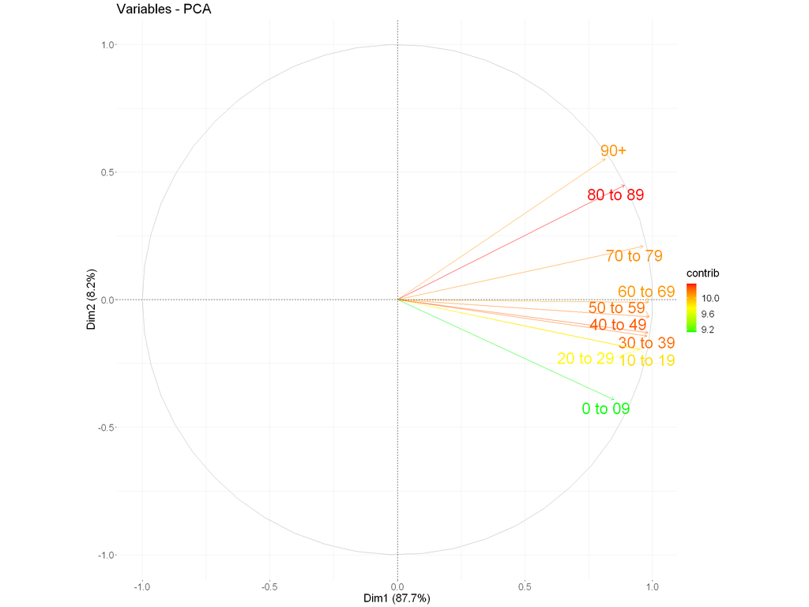

```r
fviz_pca_var(phu_scaled.pca,
             col.var = "contrib", # How will we colour our data/lines
             gradient.cols = c("green", "yellow", "red"),
             labelsize = 10,
             repel = TRUE, # make sure text doesn't overlap
             axes = c(1,2) # Determine which PCs you want to graph
            ) +
    theme(text = element_text(size=20))
```

## 3.7.0 Check if PHUs cluster or separate with `fviz_pca_ind()`

Now that we've generated our PCA, let's see if there is any clear separation between our PHUs across the first two dimensions of new features. Much like our variables, all of the individual coordinate data can be found in our `ind` element of our PCA object. Within there we'll find the `coord` information so we could directly build a ggplot with `phu_scaled.pca$ind$coord` there's a simpler way.

We'll parse through the PCA object with `fviz_pca_ind()` to plot our data along the first two principle coordinates. We can define `pointsize` and `col.ind` to help add some population size information to our PHUs.

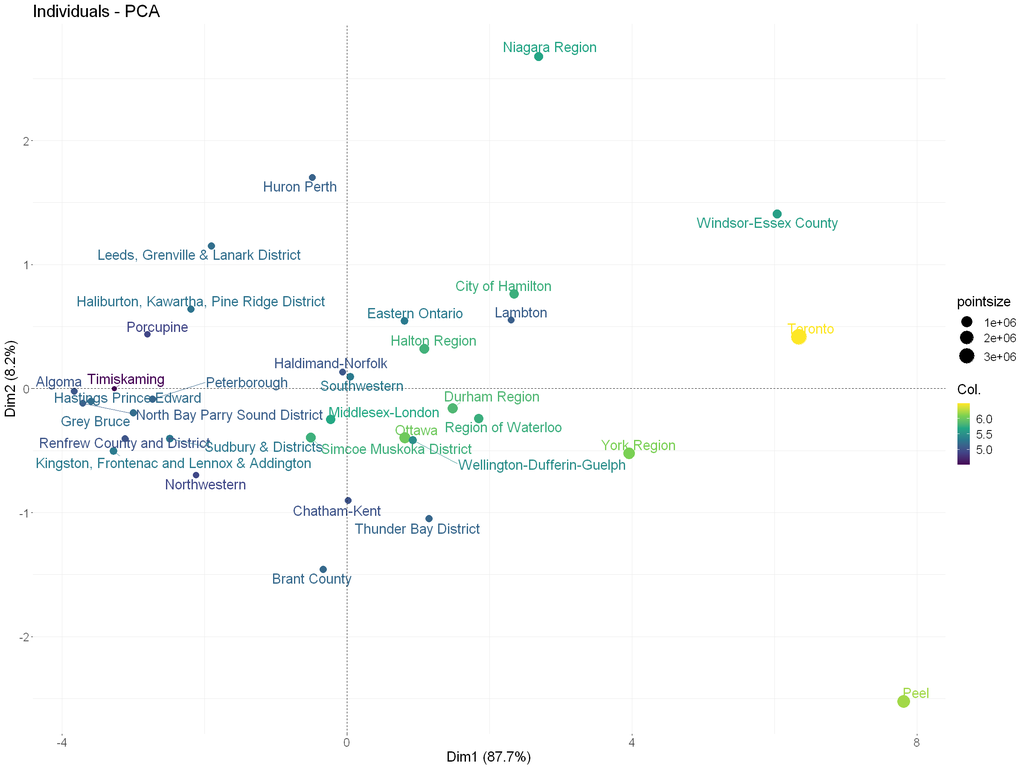

```r
# Graph our scaled PCA data.

fviz_pca_ind(phu_scaled.pca,
             pointsize = covid_demographics_norm.mx[,11], # Set point size and colour by PHU population
             col.ind = log10(covid_demographics_norm.mx[,11]),
             repel = TRUE, # avoid overlapping text points
             labelsize = 7,
             axes = c(1,2)
            ) +

    theme(text = element_text(size=20)) + # Make our text larger

    scale_size(range = c(3, 10)) + # Update the point size range

    scale_colour_viridis_c() # Change the colour scheme
```

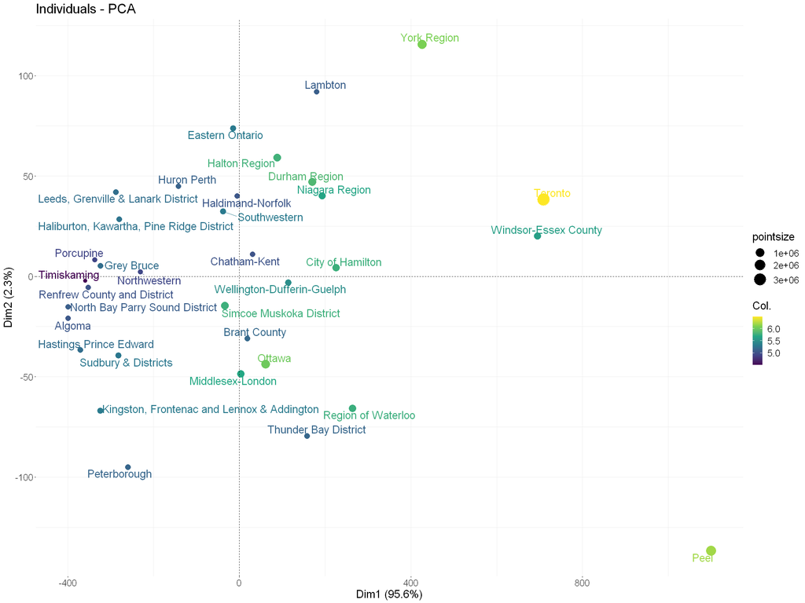

```r
# Graph our UNscaled PCA data.

fviz_pca_ind(phu_unscaled.pca,
             pointsize = covid_demographics_norm.mx[,11], # Set point size and colour by PHU population
             col.ind = log10(covid_demographics_norm.mx[,11]),
             repel = TRUE, # avoid overlapping text points
             labelsize = 7,
             axes = c(1,2)
            ) +

    theme(text = element_text(size=20)) + # Make our text larger

    scale_size(range = c(3, 10)) + # Update the point size range

    scale_colour_viridis_c() # Change the colour scheme
```

```r
phu_unscaled.pca$var
```

**$coord**

A matrix: 10 × 10 of type dbl

|  | Dim.1 | Dim.2 | Dim.3 | Dim.4 | Dim.5 | Dim.6 | Dim.7 | Dim.8 | Dim.9 | Dim.10 |
| --- | --- | --- | --- | --- | --- | --- | --- | --- | --- | --- |
| 0 to 09 | 37.49455 | -2.9493712 | -14.705680 | 3.943741 | 10.1504291 | 10.7424237 | 3.2566042 | 2.16144737 | 0.13920690 | -0.138159107 |
| 10 to 19 | 78.29497 | 4.3519387 | -13.905397 | 17.526820 | -0.7289332 | -6.3746997 | -0.3411654 | -2.70120162 | -0.06568551 | 0.063127922 |
| 20 to 29 | 203.87873 | -37.3919796 | 10.039886 | 3.644294 | -2.7490394 | 1.6924686 | -0.4819387 | 0.93421527 | 0.19696450 | 0.003331505 |
| 30 to 39 | 153.04950 | 0.8065284 | -2.671534 | -11.737372 | 9.3047870 | -4.3034663 | 1.3508393 | -4.28493423 | -0.50723112 | -0.083395861 |
| 40 to 49 | 135.82520 | 13.0139749 | -9.033290 | -4.695088 | -0.4023234 | -6.8541026 | -2.2598567 | 5.92566904 | 0.26046843 | 0.151799504 |
| 50 to 59 | 136.07230 | 21.7815690 | -2.328866 | -1.883309 | -7.4536578 | 9.5843601 | -5.0542242 | -1.91515053 | -0.75217273 | -0.059932559 |
| 60 to 69 | 82.05870 | 15.6257014 | 4.098344 | -0.418345 | -6.1244984 | 0.7367728 | 8.7412257 | -0.32205500 | 2.74095649 | 0.151228580 |
| 70 to 79 | 42.88774 | 12.3960894 | 10.740811 | 4.129898 | 0.4341420 | -0.5531776 | 4.7261810 | 1.33025267 | -4.41566435 | 0.012627377 |
| 80 to 89 | 33.71914 | 15.6590851 | 15.488810 | 6.025743 | 6.7773602 | -0.7392692 | -2.4483108 | 0.63885573 | 1.51527013 | -1.284631066 |
| 90+ | 19.00770 | 10.3363845 | 11.925837 | 4.275937 | 7.2164407 | 1.3098353 | -2.4532226 | -0.03333489 | 0.93301984 | 1.590120421 |

**$cor**

A matrix: 10 × 10 of type dbl

|  | Dim.1 | Dim.2 | Dim.3 | Dim.4 | Dim.5 | Dim.6 | Dim.7 | Dim.8 | Dim.9 | Dim.10 |
| --- | --- | --- | --- | --- | --- | --- | --- | --- | --- | --- |
| 0 to 09 | 0.8647251 | -0.06802042 | -0.33915245 | 0.090953256 | 0.234096144 | 0.247749127 | 0.075106035 | 0.049848779 | 0.0032104848 | -3.186320e-03 |
| 10 to 19 | 0.9566552 | 0.05317461 | -0.16990454 | 0.214153273 | -0.008906546 | -0.077889930 | -0.004168565 | -0.033004912 | -0.0008025852 | 7.713351e-04 |
| 20 to 29 | 0.9821593 | -0.18013101 | 0.04836585 | 0.017555915 | -0.013243141 | 0.008153248 | -0.002321677 | 0.004500461 | 0.0009488509 | 1.604909e-05 |
| 30 to 39 | 0.9942629 | 0.00523949 | -0.01735522 | -0.076250063 | 0.060447141 | -0.027956818 | 0.008775523 | -0.027836427 | -0.0032951502 | -5.417686e-04 |
| 40 to 49 | 0.9903715 | 0.09489159 | -0.06586637 | -0.034234304 | -0.002933547 | -0.049976792 | -0.016477779 | 0.043207104 | 0.0018992095 | 1.106848e-03 |
| 50 to 59 | 0.9826245 | 0.15729213 | -0.01681753 | -0.013600016 | -0.053825402 | 0.069211930 | -0.036498275 | -0.013829955 | -0.0054316956 | -4.327934e-04 |
| 60 to 69 | 0.9727030 | 0.18522309 | 0.04858072 | -0.004958956 | -0.072598248 | 0.008733518 | 0.103616269 | -0.003817558 | 0.0324906018 | 1.792625e-03 |
| 70 to 79 | 0.9207658 | 0.26613422 | 0.23059670 | 0.088665638 | 0.009320684 | -0.011876284 | 0.101467364 | 0.028559472 | -0.0948008175 | 2.710998e-04 |
| 80 to 89 | 0.8141709 | 0.37809892 | 0.37398751 | 0.145495522 | 0.163643824 | -0.017850142 | -0.059116076 | 0.015425592 | 0.0365871952 | -3.101826e-02 |
| 90+ | 0.7226406 | 0.39297191 | 0.45340023 | 0.162563928 | 0.274356908 | 0.049797731 | -0.093267389 | -0.001267336 | 0.0354718413 | 6.045370e-02 |

**$cos2**

A matrix: 10 × 10 of type dbl

|  | Dim.1 | Dim.2 | Dim.3 | Dim.4 | Dim.5 | Dim.6 | Dim.7 | Dim.8 | Dim.9 | Dim.10 |
| --- | --- | --- | --- | --- | --- | --- | --- | --- | --- | --- |
| 0 to 09 | 0.7477494 | 4.626777e-03 | 0.1150243868 | 8.272495e-03 | 5.480100e-02 | 6.137963e-02 | 5.640916e-03 | 2.484901e-03 | 1.030721e-05 | 1.015263e-05 |
| 10 to 19 | 0.9151892 | 2.827540e-03 | 0.0288675529 | 4.586162e-02 | 7.932657e-05 | 6.066841e-03 | 1.737694e-05 | 1.089324e-03 | 6.441430e-07 | 5.949578e-07 |
| 20 to 29 | 0.9646370 | 3.244718e-02 | 0.0023392553 | 3.082102e-04 | 1.753808e-04 | 6.647545e-05 | 5.390186e-06 | 2.025415e-05 | 9.003181e-07 | 2.575734e-10 |
| 30 to 39 | 0.9885588 | 2.745225e-05 | 0.0003012035 | 5.814072e-03 | 3.653857e-03 | 7.815837e-04 | 7.700981e-05 | 7.748667e-04 | 1.085802e-05 | 2.935132e-07 |
| 40 to 49 | 0.9808357 | 9.004414e-03 | 0.0043383787 | 1.171988e-03 | 8.605700e-06 | 2.497680e-03 | 2.715172e-04 | 1.866854e-03 | 3.606997e-06 | 1.225113e-06 |
| 50 to 59 | 0.9655508 | 2.474081e-02 | 0.0002828295 | 1.849604e-04 | 2.897174e-03 | 4.790291e-03 | 1.332124e-03 | 1.912676e-04 | 2.950332e-05 | 1.873102e-07 |
| 60 to 69 | 0.9461512 | 3.430759e-02 | 0.0023600868 | 2.459124e-05 | 5.270506e-03 | 7.627434e-05 | 1.073633e-02 | 1.457375e-05 | 1.055639e-03 | 3.213505e-06 |
| 70 to 79 | 0.8478097 | 7.082743e-02 | 0.0531748383 | 7.861595e-03 | 8.687515e-05 | 1.410461e-04 | 1.029563e-02 | 8.156434e-04 | 8.987195e-03 | 7.349510e-08 |
| 80 to 89 | 0.6628743 | 1.429588e-01 | 0.1398666544 | 2.116895e-02 | 2.677930e-02 | 3.186276e-04 | 3.494710e-03 | 2.379489e-04 | 1.338623e-03 | 9.621326e-04 |
| 90+ | 0.5222094 | 1.544269e-01 | 0.2055717679 | 2.642703e-02 | 7.527171e-02 | 2.479814e-03 | 8.698806e-03 | 1.606142e-06 | 1.258252e-03 | 3.654650e-03 |

**$contrib**

A matrix: 10 × 10 of type dbl

|  | Dim.1 | Dim.2 | Dim.3 | Dim.4 | Dim.5 | Dim.6 | Dim.7 | Dim.8 | Dim.9 | Dim.10 |
| --- | --- | --- | --- | --- | --- | --- | --- | --- | --- | --- |
| 0 to 09 | 1.1758259 | 0.30845436 | 19.3282030 | 2.72286004 | 26.47764408 | 36.1334835 | 6.87821134 | 6.464833750 | 0.06224867 | 4.482354e-01 |
| 10 to 19 | 5.1271303 | 0.67157972 | 17.2817641 | 53.77925723 | 0.13654822 | 12.7240318 | 0.07548759 | 10.096760040 | 0.01385950 | 9.358151e-02 |
| 20 to 29 | 34.7656599 | 49.57799411 | 9.0090463 | 2.32506678 | 1.94210389 | 0.8969051 | 0.15063615 | 1.207708047 | 0.12461906 | 2.606322e-04 |
| 30 to 39 | 19.5916267 | 0.02306595 | 0.6378853 | 24.11849988 | 22.24966141 | 5.7988530 | 1.18345829 | 25.407173482 | 0.82645716 | 1.633188e-01 |
| 40 to 49 | 15.4300517 | 6.00553860 | 7.2931170 | 3.85918860 | 0.04159692 | 14.7097903 | 3.31213003 | 48.589543145 | 0.21793087 | 5.411128e-01 |
| 50 to 59 | 15.4862448 | 16.82326766 | 0.4847415 | 0.62094296 | 14.27740994 | 28.7628238 | 16.56740816 | 5.075441943 | 1.81737158 | 8.434760e-02 |
| 60 to 69 | 5.6319132 | 8.65787034 | 1.5011981 | 0.03063922 | 9.63943502 | 0.1699701 | 49.55531356 | 0.143525186 | 24.13308511 | 5.370501e-01 |
| 70 to 79 | 1.5384131 | 5.44880709 | 10.3108718 | 2.98598187 | 0.04843664 | 0.0958152 | 14.48659286 | 2.448704119 | 62.63263304 | 3.744324e-03 |
| 80 to 89 | 0.9509544 | 8.69490423 | 21.4416076 | 6.35667014 | 11.80406694 | 0.1711239 | 3.88757388 | 0.564772607 | 7.37545280 | 3.875287e+01 |
| 90+ | 0.3021800 | 3.78851793 | 12.7115651 | 3.20089327 | 13.38309694 | 0.5372033 | 3.90318814 | 0.001537681 | 2.79634222 | 5.937548e+01 |

## 3.8.0 Scaled vs unscaled data

As you can see from our graphing of both PCA sets, when we choose not to scale our data something a little more drastic happens. PC1's portion of variance increases to a 95.6% accounting of overall variance. We see many of our points move and separation between many of our PHUs is decreased. Likely due to the larger range of numbers from the 20 to 29 age group.

So think carefully about your features and what they represent. Depending on their range, and unit values, you may be inadvertantly weighing them more than your other features! Scaling adjusts your data so that all features are weighted equally!

## 3.9.0 Can we cluster our transformed data?

Now that we've effectively reduced the complexity of our data, can we produce the same kmeans clustering as before? Let's try to cluster just on the two dimensions presented, which we have already graphed!

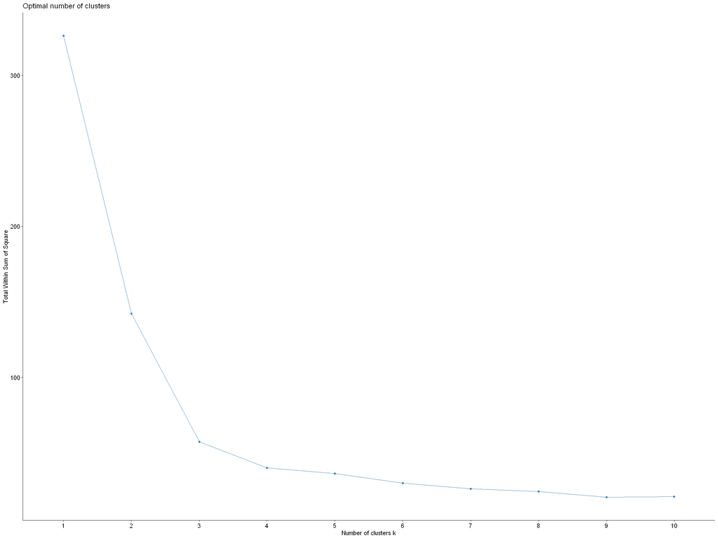

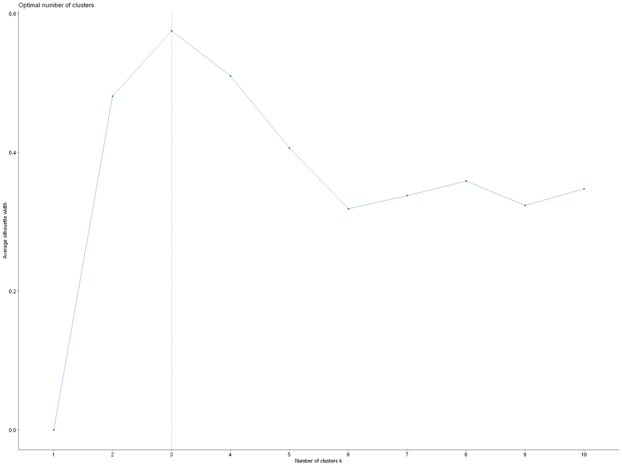

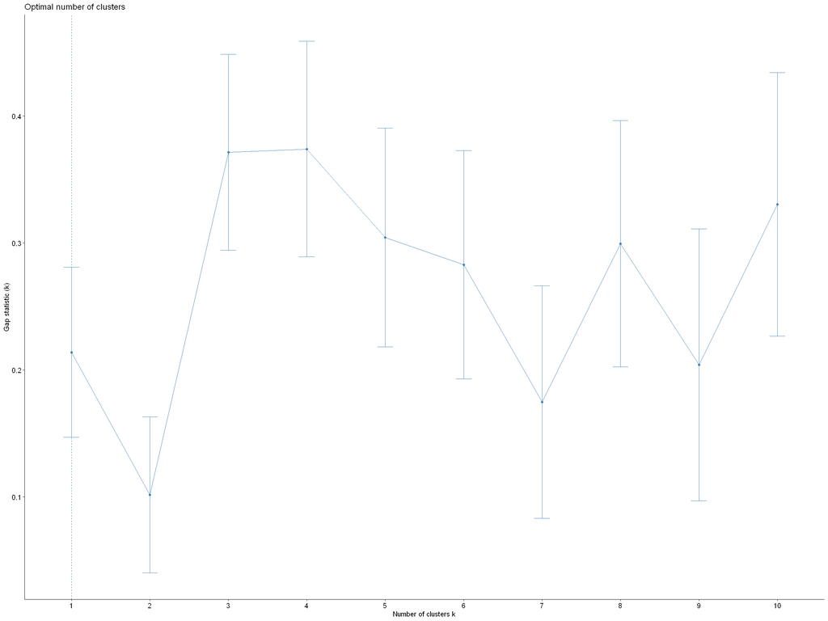

```r
# How many clusters should we use based on our PCA data?
fviz_nbclust(phu_scaled.pca$ind$coord[,1:2], kmeans, method="wss")
fviz_nbclust(phu_scaled.pca$ind$coord[,1:2], kmeans, method="silhouette")
fviz_nbclust(phu_scaled.pca$ind$coord[,1:2], kmeans, method="gap_stat")
```

```r
# Generate our kmeans analysis and visualize it

phu_PCA_kmeans.plot <-

kmeans(phu_scaled.pca$ind$coord[, 1:2], centers = 3) %>%


fviz_cluster(., # our k-means object
             data = phu_scaled.pca$ind$coord[, 1:2], # Our original data needed for PCA to visualize
             ellipse.type = "convex",
             ggtheme = theme_bw(),
             repel=TRUE, # Try to avoid overlapping text
             labelsize = 20,
             pointsize = 4,
             main = "K-means clustering of PHU by normalized case number AFTER Principal Component Analysis"
             ) +

# Set some ggplot theme information
theme(text = element_text(size=20)) +

# Set the colour and fill scheme to viridis
scale_fill_viridis_d() +
scale_colour_viridis_d()

# phu_pca_kmeans.plot
```

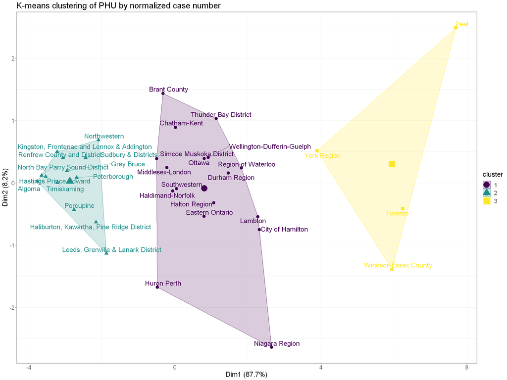

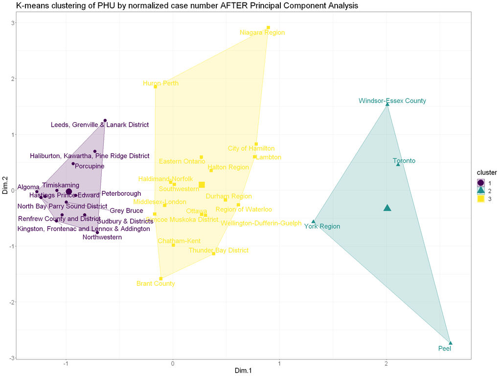

```r
# Plot both of our figures together
fig.show="hold"; out.width="50%"; out.height = "50%"
phu_kmeans.plot
phu_PCA_kmeans.plot
```

## 3.10.0 Was it worth it to use PCA?

From our estimations, the clustering choices look near identical and this is not exactly the best dataset to work with since it is rather small but you can see that we have now transformed our data into just 2 features. Could we do the same using just 2 features from our original dataset? No! So imagine transforming a much larger and feature-heavy dataset into a smaller number of features. We are also able to extract, from the data just which of our original features may really contribute to each new principal component!

Something to consider the next time you're working with a large data set!

## 4.0.0 Non-linear projection

So we just spent much of our time trying to understand how to transform our sets based on the large amounts of variation in our data. There are some limitations we've discussed but in some cases, depending on your data size you may be interested in finding small, local similarities rather than the large variation that comes with PCA.

There are two popular projections we'll discuss today but first let's put together a more complex dataset based on some RNAseq data in `GSE150316_DeseqNormCounts_final.txt` and it's companion file `2020.07.30.20165241-supp_tables.xlsx`

```r
# Read in our RNAseq data
tissue_data.df <- read.table(file = "./data/GSE150316_DeseqNormCounts_final.txt",
                             header = TRUE,
                             row.names = 1)
# Take a quick look at it
head(tissue_data.df)
dim(tissue_data.df)

# Read in some additional patient data
patient_data.df <- read_excel("./data/2020.07.30.20165241-supp_tables.xlsx", sheet=2)

# Take a quick look at it
head(patient_data.df)
dim(patient_data.df)
```

A data.frame: 6 × 88

|  | case1.lung1 <dbl> | case1.lung2 <dbl> | case1.lung3 <dbl> | case1.lung4 <dbl> | case1.heart1 <dbl> | case2.lung1 <dbl> | case2.lung2 <dbl> | case2.jejunum1 <dbl> | case2.lung3 <dbl> | case2.heart1 <dbl> | ... | caseP4.placenta1 <dbl> | caseF.lung.NYC <dbl> | caseE.lung.NYC <dbl> | caseG.lung.NYC <dbl> | caseH.lung.NYC <dbl> | caseI.lung.NYC <dbl> | caseJ.lung.NYC <dbl> | case3.liver1 <dbl> | case10.liver1 <dbl> | case12.liver1 <dbl> |
| --- | --- | --- | --- | --- | --- | --- | --- | --- | --- | --- | --- | --- | --- | --- | --- | --- | --- | --- | --- | --- | --- |
| 5S_rRNA | 7.96319457 | 4.5713330 | 7.6071080 | 39.461459 | 225.083082 | 3.7434610 | 7.1978551 | 1.7137780 | 2.195275 | 11.33237 | ... | 5.1152960 | 2.0354397 | 13.931242 | 7.0430417 | 3.5559007 | 222.868159 | 8.437777 | 117.519303 | 156.222134 | 4907.10184 |
| 5_8S_rRNA | 1.01657803 | 0.0000000 | 1.0867297 | 10.961516 | 83.364104 | 1.4037979 | 1.6936130 | 0.0000000 | 2.927033 | 12.20409 | ... | 0.2692261 | 0.2907771 | 10.216244 | 3.3143726 | 0.0000000 | 81.613692 | 7.500246 | 42.476857 | 32.888870 | 687.61937 |
| 7SK | 0.42357418 | 0.0000000 | 0.0000000 | 2.192303 | 2.778803 | 0.0000000 | 0.4234032 | 0.0000000 | 0.000000 | 0.00000 | ... | 2.9614871 | 0.0000000 | 2.786248 | 0.8285931 | 1.6163185 | 0.000000 | 2.343827 | 1.415895 | 8.222218 | 0.00000 |
| A1BG | 0.16942967 | 0.0000000 | 0.5433649 | 0.000000 | 2.778803 | 0.0000000 | 0.8468065 | 0.0000000 | 0.000000 | 0.00000 | ... | 0.2692261 | 0.0000000 | 0.000000 | 0.0000000 | 0.0000000 | 0.000000 | 0.000000 | 8.495371 | 0.000000 | 31.25543 |
| A1BG-AS1 | 0.16942967 | 0.9142666 | 0.5433649 | 8.769213 | 0.000000 | 0.4679326 | 0.8468065 | 0.0000000 | 1.829396 | 0.00000 | ... | 0.2692261 | 0.2907771 | 0.000000 | 0.0000000 | 0.9697911 | 0.000000 | 0.000000 | 4.247686 | 0.000000 | 0.00000 |
| A1CF | 0.08471484 | 0.0000000 | 0.5433649 | 0.000000 | 36.124445 | 0.0000000 | 0.0000000 | 0.4284445 | 0.000000 | 0.00000 | ... | 0.0000000 | 0.0000000 | 0.000000 | 0.0000000 | 0.3232637 | 9.416964 | 0.000000 | 89.201399 | 73.999958 | 0.00000 |

1. 59090

2. 88

A tibble: 6 × 18

| Case No <chr> | Viral high vs. viral low* <chr> | Viral load (% positive tissue area by RNA ISH) <chr> | ISH hyaline membrane reactivity <chr> | RNA seq coverage <chr> | qRT PCR** <chr> | Keratin cells / mm2 <chr> | Napsin A cells / mm2 <chr> | CD1 63 cells/ mm2 <chr> | CD 3 Cells/ mm2 <chr> | CD 4 cells/ mm2 <chr> | CD8 cells/ mm2 <chr> | CD20 cells/ mm2 <chr> | CD123 cells/ mm2 <chr> | CD18 cells/ mm2 <chr> | CD56 cells/ mm2 <chr> | IDO1 cells/ mm2 <chr> | PD L1 cells/ mm2 <chr> |
| --- | --- | --- | --- | --- | --- | --- | --- | --- | --- | --- | --- | --- | --- | --- | --- | --- | --- |
| 1 | High | 81.2 | Present | 99.96 | Positive | 192 | 174 | 216 | 174 | 98 | 24 | 17 | 6 | 3 | 59 | 51 | 50 |
| 2 | Low | 0.5 | Absent | 9.4 | Positive | 335 | 429 | 1026 | 420 | 225 | 78 | 21 | 63 | 17 | 31 | 68 | 13 |
| 3 | Low | 2 | Absent | 1.27 | Positive | 663 | 474 | 855 | 956 | 354 | 212 | 51 | 14 | 3 | 25 | 52 | 1 |
| 4 | Low | <0.01 | Absent | 0.15 | Negative | 1045 | 680 | 723 | 290 | 152 | 39 | 23 | 31 | 7 | 54 | 27 | 1 |
| 5 | High | 18.5 | Present | 24.27 | Positive | 478 | 183 | 1010 | 386 | 203 | 65 | 12 | 4 | 2 | 20 | 28 | 10 |
| 6 | Low | 0.02 | Absent | 0.17 | Negative | 198 | 294 | 317 | 167 | 50 | 10 | 15 | 3 | 0.4 | 24 | 11 | 0.2 |

1. 24

2. 18

## 4.0.1 Reformat our patient data

First let's get a hold of our patient data (24 patient samples listed in total) and reformat the column names a bit before selecting for just the viral load and viral load percentage information located in the 2nd and 3rd column. We'll hold onto this in `patient_viral_load.df` for later use.

```r
patient_viral_load.df <-
patient_data.df %>%
rename_with(str_replace_all, pattern="\\r\\n|\\s", replacement = "_") %>%
select(1:3)
```

## 4.0.2 Prepare our RNAseq tissue data for analysis by eliminating features

We now want to format our RNAseq data much in the way we did with our PHU data. We want to convert our current data which lists genes as observations and tissue samples as columns. Essentially, we'd like to transpose this and we *could* do that but the transposition converts everything to a matrix. In the end, we want to work with a data frame so we can hold more information.

First, however, to reduce on memory and runtime, we should trim our dataset. We aren't really interested in looking at 59090 genes - many of which may be barely expressed. Since these are normalized counts across the dataset, we can filter out low-expression genes to make `tissue_data_filtered.df`. Yes, this would be considered a form of *feature elimination*.

```r
# Trim the tissue data down
tissue_data_filtered.df <-

tissue_data.df %>%

# Convert the row names to a column
rownames_to_column(var="gene") %>%

# Set up the table to perform row-wise operations
rowwise() %>%

# Calculate the mean expression of each gene across all tissue samples
mutate(mean = mean(c_across(where(is.numeric)))) %>%

# Filter for samples with low expression
filter(mean > 0.5) %>%

# Calculate overall variance in case we need to make our dataset smaller
mutate(variance = var(c_across(where(is.numeric)))) %>%

# Arrange samples by descending variance
arrange(desc(variance)) %>%

# Remove the grouping specification
ungroup()

# Take a look at the final results
head(tissue_data_filtered.df)

# how big is our filtered data frame?
dim(tissue_data_filtered.df)
```

A tibble: 6 × 91

| gene <chr> | case1.lung1 <dbl> | case1.lung2 <dbl> | case1.lung3 <dbl> | case1.lung4 <dbl> | case1.heart1 <dbl> | case2.lung1 <dbl> | case2.lung2 <dbl> | case2.jejunum1 <dbl> | case2.lung3 <dbl> | ... | caseE.lung.NYC <dbl> | caseG.lung.NYC <dbl> | caseH.lung.NYC <dbl> | caseI.lung.NYC <dbl> | caseJ.lung.NYC <dbl> | case3.liver1 <dbl> | case10.liver1 <dbl> | case12.liver1 <dbl> | mean <dbl> | variance <dbl> |
| --- | --- | --- | --- | --- | --- | --- | --- | --- | --- | --- | --- | --- | --- | --- | --- | --- | --- | --- | --- | --- |
| MT-ND5 | 148.16625 | 223.53818 | 328.1924 | 541.4989 | 4854.570 | 6289.014 | 3615.440 | 6206.875 | 3324.012 | ... | 5588.286 | 2873.147 | 4517.287 | 4058.712 | 3616.994 | 11243.624 | 44210.8638 | 18409.446 | 9103.401 | 875863420 |
| MT-RNR2 | 1819.92882 | 1450.02682 | 3469.9280 | 4106.1840 | 21257.847 | 5766.334 | 6830.764 | 3656.345 | 5538.313 | ... | 22644.770 | 8076.297 | 5696.230 | 14304.369 | 9613.440 | 40631.945 | 15128.8803 | 74200.381 | 14253.287 | 293052270 |
| MT-ND6 | 56.58951 | 79.99833 | 146.1651 | 190.7304 | 1889.586 | 2698.099 | 1279.525 | 2287.894 | 1129.835 | ... | 2432.395 | 1045.685 | 1871.697 | 1271.290 | 1227.228 | 5444.117 | 20506.2106 | 4344.504 | 3918.828 | 186366040 |
| MT-ND4 | 271.17219 | 335.99297 | 484.6815 | 506.4221 | 7808.438 | 7505.639 | 3720.868 | 6911.667 | 3504.391 | ... | 6336.858 | 4030.691 | 4382.809 | 5019.242 | 3833.095 | 13156.498 | 74945.5130 | 35724.952 | 7482.174 | 159946583 |
| MT-CO1 | 201.96017 | 378.04924 | 431.4317 | 530.5374 | 7135.967 | 4354.581 | 2830.027 | 4528.658 | 2828.612 | ... | 4053.063 | 3421.675 | 4255.443 | 4595.479 | 3880.909 | 19814.038 | 35733.7575 | 17440.528 | 6039.659 | 88805600 |
| MALAT1 | 13603.08476 | 21286.41203 | 22529.5371 | 30872.0147 | 22994.599 | 19772.025 | 21814.158 | 13768.064 | 20359.346 | ... | 21388.172 | 16218.882 | 22934.913 | 16259.959 | 14288.906 | 16607.035 | 633.1108 | 8563.987 | 19115.219 | 63149355 |

1. 29220

2. 91

## 4.0.3 More data wrangling to transpose our RNAseq data

1. We'll tranpose our data using a combination of `pivot_longer()` and `pivot_wider()`.
2. We'll use a series of string matches and joins to add some sample information to our data. It won't be used for our analysis but will be used when we plot the results!
3. Lastly we'll convert the relevant parts of our data frame to a matrix. There is a huge memory savings in the algorithm when working with a matrix and you have limited memory on your Jupyter Hubs!

```r
# You need to transpose the data.
# We can do it with dplyr to keep it as a data frame and to add some info

tissue_RNAseq.df <-

tissue_data_filtered.df %>%

select(1:89) %>% # trim down the columns

pivot_longer(cols=c(2:89), names_to = "sample", values_to = "norm_counts") %>%

pivot_wider(names_from = gene, values_from = norm_counts)

# str(tissue_RNAseq.df)
```

```r
# We want to add some additional sample information before assessing the data

tissue_RNAseq.df <-

tissue_RNAseq.df %>%

# Grab just the sample names
select(sample) %>%

# Grab information from it like case number, tissue, and tissue number
str_match_all(., pattern=c("case([\\w]+)\\.([a-z]+)([\\d|\\.NYC]*)|(NegControl\\d)")) %>%

# Bind it all together
do.call(rbind, .) %>%

# Convert the results to a data frame
as.data.frame() %>%

# Rename the columns based on the capture groups
rename(., sample = V1, case_num = V2, tissue = V3, tissue_num = V4, neg_num = V5) %>%

# Coalesce some of the info due to negative control samples and clean up a column
mutate(case_num = coalesce(case_num, neg_num),
       tissue_num = str_replace_all(.$tissue_num, pattern = "\\.", replace = "")) %>%

# Drop the neg_num column
select(1:4) %>%

# Join this result to the RNAseq info
full_join(., y=tissue_RNAseq.df, by=c("sample" = "sample")) %>%

# Join that result to grab viral load information
right_join(patient_viral_load.df, y=., by=c("Case_No" = "case_num")) %>%

# Fix some column names
rename(case_num = Case_No,
       viral_load = `Viral_high_vs._viral_low*`,
       viral_load_percent = `Viral_load_(%_positive_tissue_area_by_RNA_ISH)`)

head(tissue_RNAseq.df)
```

A tibble: 6 × 29226

| case_num <chr> | viral_load <chr> | viral_load_percent <chr> | sample <chr> | tissue <chr> | tissue_num <chr> | MT-ND5 <dbl> | MT-RNR2 <dbl> | MT-ND6 <dbl> | MT-ND4 <dbl> | ... | ZSCAN32 <dbl> | SUGT1P2 <dbl> | XX-FW83563B9.5 <dbl> | CTC-506B8.1 <dbl> | RPS15AP10 <dbl> | RP11-157P1.4 <dbl> | WASH1 <dbl> | CTD-3157E16.1 <dbl> | CSNK2A3 <dbl> | RP11-568G11.4 <dbl> |
| --- | --- | --- | --- | --- | --- | --- | --- | --- | --- | --- | --- | --- | --- | --- | --- | --- | --- | --- | --- | --- |
| 1 | High | 81.2 | case1.lung1 | lung | 1 | 148.1662 | 1819.929 | 56.58951 | 271.1722 | ... | 0.1694297 | 0.4235742 | 0.2541445 | 0.08471484 | 0.6777187 | 0.5930039 | 1.5248670 | 1.016578 | 0.5930039 | 0.5930039 |
| 1 | High | 81.2 | case1.lung2 | lung | 2 | 223.5382 | 1450.027 | 79.99833 | 335.9930 | ... | 0.4571333 | 0.0000000 | 0.4571333 | 0.45713330 | 1.3713999 | 1.3713999 | 0.9142666 | 1.828533 | 0.4571333 | 1.8285332 |
| 1 | High | 81.2 | case1.lung3 | lung | 3 | 328.1924 | 3469.928 | 146.16515 | 484.6815 | ... | 1.0867297 | 0.5433649 | 0.5433649 | 0.54336486 | 1.6300946 | 1.6300946 | 0.0000000 | 0.000000 | 0.0000000 | 1.0867297 |
| 1 | High | 81.2 | case1.lung4 | lung | 4 | 541.4989 | 4106.184 | 190.73039 | 506.4221 | ... | 0.0000000 | 2.1923033 | 0.0000000 | 0.00000000 | 0.0000000 | 0.0000000 | 0.0000000 | 0.000000 | 2.1923033 | 0.0000000 |
| 1 | High | 81.2 | case1.heart1 | heart | 1 | 4854.5697 | 21257.847 | 1889.58637 | 7808.4378 | ... | 0.0000000 | 2.7788035 | 0.0000000 | 0.00000000 | 0.0000000 | 0.0000000 | 5.5576070 | 0.000000 | 0.0000000 | 0.0000000 |
| 2 | Low | 0.5 | case2.lung1 | lung | 1 | 6289.0144 | 5766.334 | 2698.09948 | 7505.6392 | ... | 0.0000000 | 0.9358652 | 0.4679326 | 4.67932620 | 0.9358652 | 1.4037979 | 0.4679326 | 0.000000 | 0.0000000 | 0.4679326 |

```r
str(tissue_RNAseq.df)
```

```
tibble [88 x 29,226] (S3: tbl_df/tbl/data.frame)
 $ case_num                    : chr [1:88] "1" "1" "1" "1" ...
 $ viral_load                  : chr [1:88] "High" "High" "High" "High" ...
 $ viral_load_percent          : chr [1:88] "81.2" "81.2" "81.2" "81.2" ...
 $ sample                      : chr [1:88] "case1.lung1" "case1.lung2" "case1.lung3" "case1.lung4" ...
 $ tissue                      : chr [1:88] "lung" "lung" "lung" "lung" ...
 $ tissue_num                  : chr [1:88] "1" "2" "3" "4" ...
 $ MT-ND5                      : num [1:88] 148 224 328 541 4855 ...
 $ MT-RNR2                     : num [1:88] 1820 1450 3470 4106 21258 ...
 $ MT-ND6                      : num [1:88] 56.6 80 146.2 190.7 1889.6 ...
 $ MT-ND4                      : num [1:88] 271 336 485 506 7808 ...
 $ MT-CO1                      : num [1:88] 202 378 431 531 7136 ...
 $ MALAT1                      : num [1:88] 13603 21286 22530 30872 22995 ...
 $ TTN                         : num [1:88] 65.7 57.1 40.2 96.5 3042.8 ...
 $ MT-CYB                      : num [1:88] 62.2 98.7 153.8 171 3832 ...
```

[output cut: 86 more lines]

```r
tissue_RNAseq2.df <- drop_na(tissue_RNAseq.df)

str(tissue_RNAseq2.df )
```

```
tibble [66 x 29,226] (S3: tbl_df/tbl/data.frame)
 $ case_num                    : chr [1:66] "1" "1" "1" "1" ...
 $ viral_load                  : chr [1:66] "High" "High" "High" "High" ...
 $ viral_load_percent          : chr [1:66] "81.2" "81.2" "81.2" "81.2" ...
 $ sample                      : chr [1:66] "case1.lung1" "case1.lung2" "case1.lung3" "case1.lung4" ...
 $ tissue                      : chr [1:66] "lung" "lung" "lung" "lung" ...
 $ tissue_num                  : chr [1:66] "1" "2" "3" "4" ...
 $ MT-ND5                      : num [1:66] 148 224 328 541 4855 ...
 $ MT-RNR2                     : num [1:66] 1820 1450 3470 4106 21258 ...
 $ MT-ND6                      : num [1:66] 56.6 80 146.2 190.7 1889.6 ...
 $ MT-ND4                      : num [1:66] 271 336 485 506 7808 ...
 $ MT-CO1                      : num [1:66] 202 378 431 531 7136 ...
 $ MALAT1                      : num [1:66] 13603 21286 22530 30872 22995 ...
 $ TTN                         : num [1:66] 65.7 57.1 40.2 96.5 3042.8 ...
 $ MT-CYB                      : num [1:66] 62.2 98.7 153.8 171 3832 ...
```

[output cut: 86 more lines]

```r
# How many tissue types do we have?
table(tissue_RNAseq.df$tissue)
```

```
   bowel      fat    heart  jejunum   kidney    liver     lung   marrow
       4        1        7        1        3        6       52        1
placenta     skin
       7        1
```

```r
# Generate a matrix version of our data but drop the sample information!
tissue_RNAseq.mx <- as.matrix(tissue_RNAseq.df[,c(-1:-6)])

str(tissue_RNAseq.df)
str(tissue_RNAseq.mx)
```

```
tibble [88 x 29,226] (S3: tbl_df/tbl/data.frame)
 $ case_num                    : chr [1:88] "1" "1" "1" "1" ...
 $ viral_load                  : chr [1:88] "High" "High" "High" "High" ...
 $ viral_load_percent          : chr [1:88] "81.2" "81.2" "81.2" "81.2" ...
 $ sample                      : chr [1:88] "case1.lung1" "case1.lung2" "case1.lung3" "case1.lung4" ...
 $ tissue                      : chr [1:88] "lung" "lung" "lung" "lung" ...
 $ tissue_num                  : chr [1:88] "1" "2" "3" "4" ...
 $ MT-ND5                      : num [1:88] 148 224 328 541 4855 ...
 $ MT-RNR2                     : num [1:88] 1820 1450 3470 4106 21258 ...
 $ MT-ND6                      : num [1:88] 56.6 80 146.2 190.7 1889.6 ...
 $ MT-ND4                      : num [1:88] 271 336 485 506 7808 ...
 $ MT-CO1                      : num [1:88] 202 378 431 531 7136 ...
 $ MALAT1                      : num [1:88] 13603 21286 22530 30872 22995 ...
 $ TTN                         : num [1:88] 65.7 57.1 40.2 96.5 3042.8 ...
 $ MT-CYB                      : num [1:88] 62.2 98.7 153.8 171 3832 ...
```

[output cut: 90 more lines]

## 4.1.0 t-Distributed Stochastic Neighbour Embedding with the `Rtsne` package

t-Distributed Stochastic Neighbour Embedding or t-SNE is a way for us to project our high-dimension data onto a lower dimension with the aim at preserving the local similarities rather than global disparity. When looking at data points, t-SNE will attempt to preserve the local neighbouring structure. As the algorithm pours over the data, it can use different transformations for different regions as it attempts to transform everything to a lower dimension. It is considered "incredibly flexible" at finding local structure where other algorithms may not.

1. *Reduce dimensionality of your data features with PCA!*
2. Generate a probability distribution between all pairs by making similar objects highly probably and assigning dissimilar objects a low probability.
3. Define a similar probability distribution for the samples in a lower dimension while minimizing the divergence between the two distributions based on a distance metric between points in the lower dimension.

We'll discuss more about how this algorithm affect interpretation after seeing the results, but this is considered an *exploratory* data visualization tool, rather than *explanatory*.

To produce our t-SNE projection we'll use the `Rtsne()` function from the package of the same name. Some important parameters are:

- `X` is our data matrix where each row is an observation
- `dims` sets the number of dimensions we'd like to project onto (default is 2).
- `initial_dims` sets the number of dimensions that should be retained in the initial PCA step (Default 50).
- `perplexity` a numeric parameter that tunes between local and global aspects of your data.
  - It is like a guess as to how many close neighbours a point may have. If you have a sense of sample types (or clusters!) ahead of time, you could try to play with this value (default is 30).
  - According to the algorithm this value should follow this rule: $perplexity * 3 \lt nrow(X) -1$
- `pca_scale` is a boolean to set if the initial PCA step should use scaled data.
- `max_iter` is the maximum number of iterations in the algorithm (default is 1000).

```r
# Rtsne prefers using a matrix for memory issues
# set a seed for reproducible results
set.seed(1981)

# Try for perplexity of 30 can go as high as 29 before crash
# We have just 90 samples, but between 1-52 samples per "group"
tissue_tsne <- Rtsne(tissue_RNAseq.mx,
                     dims=2,
                     perplexity=5,
                     verbose=TRUE,
#                      pca_scale = TRUE,
                     max_iter = 1500)
```

```
Performing PCA
Read the 88 x 50 data matrix successfully!
OpenMP is working. 1 threads.
Using no_dims = 2, perplexity = 5.000000, and theta = 0.500000
Computing input similarities...
Building tree...
Done in 0.01 seconds (sparsity = 0.269886)!
Learning embedding...
Iteration 50: error is 73.706683 (50 iterations in 0.02 seconds)
Iteration 100: error is 70.333324 (50 iterations in 0.02 seconds)
Iteration 150: error is 74.521778 (50 iterations in 0.03 seconds)
Iteration 200: error is 75.213750 (50 iterations in 0.03 seconds)
Iteration 250: error is 70.691807 (50 iterations in 0.03 seconds)
Iteration 300: error is 2.394257 (50 iterations in 0.02 seconds)
Iteration 350: error is 1.356127 (50 iterations in 0.02 seconds)
Iteration 400: error is 0.856583 (50 iterations in 0.01 seconds)
Iteration 450: error is 0.569763 (50 iterations in 0.01 seconds)
Iteration 500: error is 0.507305 (50 iterations in 0.01 seconds)
Iteration 550: error is 0.492865 (50 iterations in 0.01 seconds)
Iteration 600: error is 0.481439 (50 iterations in 0.01 seconds)
Iteration 650: error is 0.472681 (50 iterations in 0.01 seconds)
Iteration 700: error is 0.465472 (50 iterations in 0.01 seconds)
Iteration 750: error is 0.464697 (50 iterations in 0.01 seconds)
Iteration 800: error is 0.458477 (50 iterations in 0.01 seconds)
Iteration 850: error is 0.448390 (50 iterations in 0.02 seconds)
Iteration 900: error is 0.445562 (50 iterations in 0.01 seconds)
Iteration 950: error is 0.438981 (50 iterations in 0.01 seconds)
Iteration 1000: error is 0.428277 (50 iterations in 0.01 seconds)
Iteration 1050: error is 0.417908 (50 iterations in 0.01 seconds)
Iteration 1100: error is 0.408182 (50 iterations in 0.01 seconds)
Iteration 1150: error is 0.402718 (50 iterations in 0.01 seconds)
Iteration 1200: error is 0.399624 (50 iterations in 0.02 seconds)
Iteration 1250: error is 0.399220 (50 iterations in 0.01 seconds)
Iteration 1300: error is 0.397804 (50 iterations in 0.02 seconds)
Iteration 1350: error is 0.394295 (50 iterations in 0.01 seconds)
Iteration 1400: error is 0.396083 (50 iterations in 0.01 seconds)
Iteration 1450: error is 0.394249 (50 iterations in 0.01 seconds)
Iteration 1500: error is 0.394835 (50 iterations in 0.01 seconds)
Fitting performed in 0.49 seconds.
```

```r
str(tissue_tsne)
```

```
List of 14
 $ N                  : int 88
 $ Y                  : num [1:88, 1:2] 6.12 3.65 2.84 1.25 -15.2 ...
 $ costs              : num [1:88] 0.01294 0.00155 0.00388 0.00157 0.00337 ...
 $ itercosts          : num [1:30] 73.7 70.3 74.5 75.2 70.7 ...
 $ origD              : int 50
 $ perplexity         : num 5
 $ theta              : num 0.5
 $ max_iter           : num 1500
 $ stop_lying_iter    : int 250
 $ mom_switch_iter    : int 250
 $ momentum           : num 0.5
 $ final_momentum     : num 0.8
 $ eta                : num 200
 $ exaggeration_factor: num 12
```

## 4.1.1 Extract information from our tsne object

Looking above at the result of our t-SNE analysis, we can notice a few things...

1. We get back the number of objects we put in: 88
2. The element `Y` is an 88x2 matrix holding the coordinates for our new project
3. There are no eigenvectors or other information about the variables or dimensions or how they were used in the projection!

That's right, there is no underlying information for mapping back to our original dataset. It's a completely black box with no way to reverse engineer the process. That's because the process itself is *stochastic*! Whereas PCA was a deterministic, repeatable the same way every time with the same data, that is not the case for t-SNE. That's why even though it can be quite powerful in identifying local similarities, it does not provide a mathematical pathway back to our original data!

Let's extract the information, combine it with our sample information and project it using `ggplot2`

```r
# Build our new data frame from the Y values
tissue_tsne.df <- data.frame(x.coord = tissue_tsne$Y[,1],
                             y.coord = tissue_tsne$Y[,2])

# Add in our sample information
tissue_tsne.df <- cbind(tissue_RNAseq.df[,1:6], tissue_tsne.df)

# Fix up the information just a little bit to remove NA viral load information
tissue_tsne.df <-
tissue_tsne.df %>%
mutate(viral_load = replace_na(viral_load, replace = "DNW"))

head(tissue_tsne.df)
```

A data.frame: 6 × 8

|  | case_num <chr> | viral_load <chr> | viral_load_percent <chr> | sample <chr> | tissue <chr> | tissue_num <chr> | x.coord <dbl> | y.coord <dbl> |
| --- | --- | --- | --- | --- | --- | --- | --- | --- |
| 1 | 1 | High | 81.2 | case1.lung1 | lung | 1 | 6.116854 | 16.7338349 |
| 2 | 1 | High | 81.2 | case1.lung2 | lung | 2 | 3.647073 | 17.7425355 |
| 3 | 1 | High | 81.2 | case1.lung3 | lung | 3 | 2.840894 | 18.2454507 |
| 4 | 1 | High | 81.2 | case1.lung4 | lung | 4 | 1.251879 | 19.3456706 |
| 5 | 1 | High | 81.2 | case1.heart1 | heart | 1 | -15.202523 | 4.2097605 |
| 6 | 2 | Low | 0.5 | case2.lung1 | lung | 1 | 8.544851 | 0.4172884 |

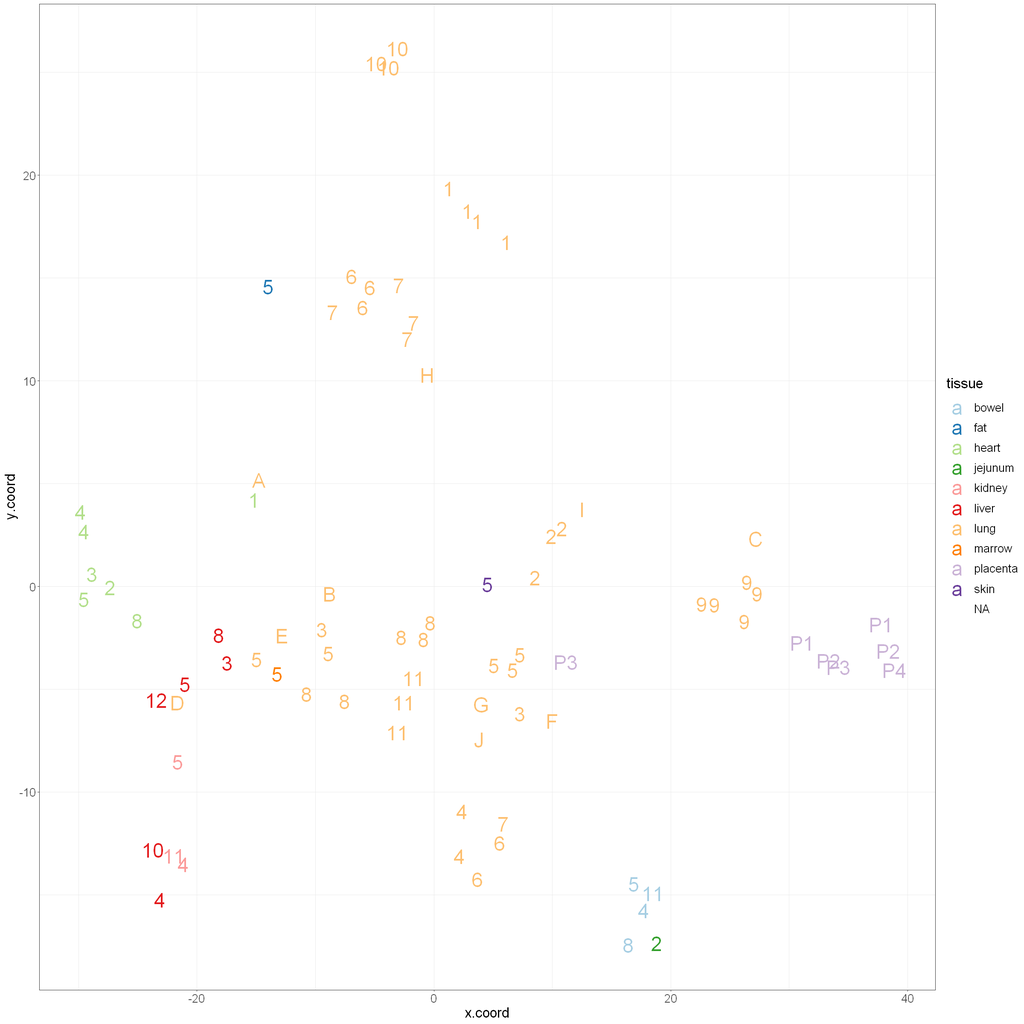

```r
# Adjust our plot window size according to the expected output
options(repr.plot.width=20, repr.plot.height=20)

combo.colours = c(brewer.pal(12, "Paired"), brewer.pal(12, "Set3"), brewer.pal(8, "Set1"))

# 1. Data
ggplot(data = tissue_tsne.df) +
    # 2. Aesthetics
    aes(x = x.coord, y = y.coord, colour = tissue) +
    # Themes
    theme_bw() +
    theme(text = element_text(size=20)) +

    # 3. Scaling
    scale_colour_manual(values = combo.colours) +

    # 4. Geoms
    geom_text(aes(label = case_num), size = 10)
```

## 4.1.2 Interpreting our t-SNE plot

While we don't have a lot of samples, you can still see that we were able to cluster *some* of our data by cell types without providing that classification to the algorithm! Great job team!

One thing we can see which is interesting is that regardless of tissue type, we see that some samples are clustering together based on case number - namely case numbers 1, 4 and 5 seem to have some strong underlying expression profiles that connect them across tissue samples. We may also be seeing false relationships so beware!

## 4.2.0 Uniform Manifold Approximation and Projection

This algorithm for projection is in the same flavour as t-SNE projection but has some differences including:

1. Increased speed and better preservation of the global structure in your data
2. A different theoretical foundation used to balance between local and global structure

What does that translate to for us? Faster results, and more interpretive results! Otherwise the same issues can apply. The setup is slightly easier with few options to change if you leave the defaults. We can access `umap()` from the package of the same name. You may also alter the default methods using by creating a `umap.defaults` object. More information on that [here](https://cran.r-project.org/web/packages/umap/umap.pdf)

For more tinkering, you can choose to use the `uwot` [package](https://rdrr.io/cran/uwot/) instead where the `umap()` function has more options that are easily modified.

```r
# Set our seed
set.seed(1981)

# Generate our projection
tissue_umap <- umap(tissue_RNAseq.mx)
```

```r
str(tissue_umap)
```

```
List of 4
 $ layout: num [1:88, 1:2] 1.016 1.424 1.705 1.809 0.972 ...
 $ data  : num [1:88, 1:29220] 148 224 328 541 4855 ...
  ..- attr(*, "dimnames")=List of 2
  .. ..$ : NULL
  .. ..$ : chr [1:29220] "MT-ND5" "MT-RNR2" "MT-ND6" "MT-ND4" ...
 $ knn   :List of 2
  ..$ indexes  : int [1:88, 1:15] 1 2 3 4 5 6 7 8 9 10 ...
  ..$ distances: num [1:88, 1:15] 0 0 0 0 0 0 0 0 0 0 ...
  ..- attr(*, "class")= chr "umap.knn"
 $ config:List of 24
  ..$ n_neighbors         : int 15
  ..$ n_components        : int 2
  ..$ metric              : chr "euclidean"
  ..$ n_epochs            : int 200
  ..$ input               : chr "data"
  ..$ init                : chr "spectral"
  ..$ min_dist            : num 0.1
  ..$ set_op_mix_ratio    : num 1
  ..$ local_connectivity  : num 1
  ..$ bandwidth           : num 1
  ..$ alpha               : num 1
  ..$ gamma               : num 1
  ..$ negative_sample_rate: int 5
  ..$ a                   : num 1.58
  ..$ b                   : num 0.895
  ..$ spread              : num 1
  ..$ random_state        : int 391567063
  ..$ transform_state     : int NA
  ..$ knn                 : logi NA
  ..$ knn_repeats         : num 1
  ..$ verbose             : logi FALSE
  ..$ umap_learn_args     : logi NA
  ..$ method              : chr "naive"
  ..$ metric.function     :function (m, origin, targets)
  ..- attr(*, "class")= chr "umap.config"
 - attr(*, "class")= chr "umap"
```

```r
# Re-map our projection points with our tissue data

tissue_umap.df <- data.frame(x.coord = tissue_umap$layout[,1],
                             y.coord = tissue_umap$layout[,2])

tissue_umap.df <- cbind(tissue_RNAseq.df[,1:6], tissue_umap.df)

tissue_umap.df <-
tissue_umap.df %>%
mutate(viral_load = replace_na(viral_load, replace = "DNW"))
```

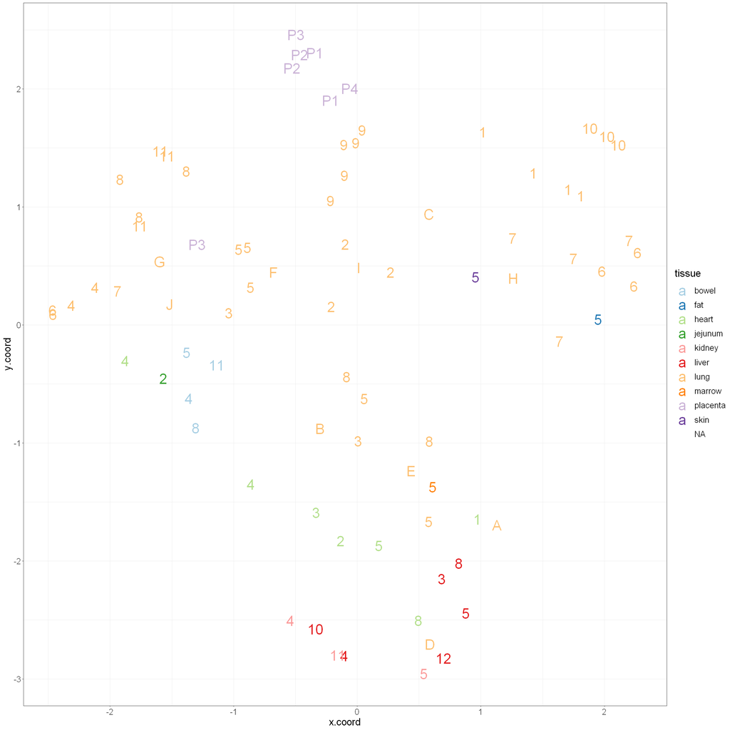

```r
# Adjust our plot window size according to the expected output
options(repr.plot.width=20, repr.plot.height=20)

combo.colours = c(brewer.pal(12, "Paired"), brewer.pal(12, "Set3"), brewer.pal(8, "Set1"))

# 1. Data
ggplot(data = tissue_umap.df) +
    # 2. Aesthetics
    aes(x = x.coord, y = y.coord, colour = tissue, shape = viral_load, ) +
    # Themes
    theme_bw() +
    theme(text = element_text(size=20)) +

    # 3. Scaling
    scale_colour_manual(values = combo.colours) +

    # 4. Geoms
    geom_text(aes(label = case_num), size = 10)
```

## 4.2.1 Interpreting our UMAP result

So it looks like without much tinkering we retrieved a fairly nice result. We can see now that liver and kidney are more closely grouped as tissues, while heart samples generally cluster together still. Bowel and jejunum have appear spatially grouped and our placenta samples are still close to each other. The clustering we saw with samples 1, 4, and 5 appear to be less severe.

There does appear to be some structure between the lung samples in different case numbers so this might be an avenue to explore next to try and see if there truly is a relationship between these groups.

## 5.0.0 Class summary

Today we took a deep dive into principal component analysis. There are of course different variants of this based on the assumptions you can make about your observations and variables like independent component analysis (ICA, non-Gaussian features) and multiple correspondence analysis (MCA, categorical features). Some additional methods can also be used to store the transformation like a PCA does, notably variational autoencoders (VAE).

Overall we should remember that while PCA can have problems in generating it's feature extraction, it is deterministic and repeatable. Also, the final results are provided in such a way that *new* observations could be transformed and projected onto the same principal components. You can also feed these components back into clustering algorithms like k-means to try and identify specific subgroups.

t-SNE and UMAP, on the other hand appear to do a much better job with high-dimensional data. They can preserve local structure and UMAP can also do a fairly good job of preserving global structure. These tools make for great exploratory anlaysis of your complex datasets. Interpretation of relationships, however, are not mathematically clear like in PCA. These are, after all projections from a higher dimension for our simpler primate brains!

## 6.0.0 Weekly assignment

This week's assignment will be found under the current lecture folder under the "assignment" subfolder. It will include a Jupyter notebook that you will use to produce the code and answers for this week's assignment. Please provide answers in markdown or code cells that immediately follow each question section.

|  | Assignment breakdown |  |
| --- | --- | --- |
| Code | 50% | - Does it follow best practices? |
|  |  | - Does it make good use of available packages? |
|  |  | - Was data prepared properly |
| Answers and Output | 50% | - Is output based on the correct dataset? |
|  |  | - Are groupings appropriate |
|  |  | - Are correct titles/axes/legends correct? |
|  |  | - Is interpretation of the graphs correct? |

Since coding styles and solutions can differ, students are encouraged to use best practices. Assignments *may* be rewarded for well-coded or elegant solutions.

You can save and download the Jupyter notebook in its native format. Submit this file to the the appropriate assignment section by 12pm on the date of our next class: April 22nd, 2021.

## 7.0.0 References

More information on calculating optimal clusters: https://www.datanovia.com/en/lessons/determining-the-optimal-number-of-clusters-3-must-know-methods/

Step-by-step how PCA works: https://builtin.com/data-science/step-step-explanation-principal-component-analysis

More PCA explanations here: https://stats.stackexchange.com/questions/2691/making-sense-of-principal-component-analysis-eigenvectors-eigenvalues

The math of PCA: https://www.cs.princeton.edu/picasso/mats/PCA-Tutorial-Intuition_jp.pdf